# Проект: Обучение с учителем: качество модели

Интернет-магазин «В один клик» столкнулась с проблемой снижением активности покупателей.

**Основная цель проекта**:

- Разработать решение, которое позволит персонализировать предложения постоянным клиентам интернет-магазина **«В один клик»**, чтобы увеличить их покупательскую активность. В данном проекте рассматривается сегмент клиентов с высокой вероятностью снижения активности и высокой прибыльностью.

**Ключевые задачи:**

- Промаркировать уровень финансовой активности постоянных покупателей («снизилась» или «прежний уровень»).
- Собрать данные по клиентам, описывающие их коммуникацию с компанией, продуктовое поведение, покупательское поведение и поведение на сайте.
- Построить модель, которая предскажет вероятность снижения покупательской активности клиента в следующие три месяца.
- Используя данные модели и данные о прибыльности клиентов, по выделенному сегменту покупателей и разработать для них персонализированные предложения.

**План работы:**

1. **Загрузка и предобработка данных**
- Подготовка данных для анализа (для датасетов **market_file.csv, market_money.csv, market_time.csv, money.csv**).
2. **Анализ данных**
- Исследовательский анализ данных для понимания распределений и выявления аномальных значений.
3. **Объединение таблиц**
- Объединие таблиц **market_file.csv, market_money.csv, market_time.csv**.
4. **Корреляционный анализ**
- Построение матрицы корреляции между признаками.
  - Удаление слабо коррелирующих с целевым признаком признаков.
  - Устранение мультиколлинеарности.
5. **Использование пайплайнов**
- Подготовка данных с использованием **ColumnTransformer**.
- Кодирование категориальных признаков **(One-Hot Encoding, Label Encoding)**.
- Масштабирование числовых признаков **(StandardScaler, MinMaxScaler)**.
- Обучение моделей: **(KNeighborsClassifier, DecisionTreeClassifier, LogisticRegression, SVC)**.
- Подбор гиперпараметров с помощью **OptunaSearchCV**.
6. **Анализ важности признаков**
- Оценка важности признаков для лучшей модели с помощью SHAP.
- Построение графика важности признаков.
7. **Сегментация покупателей**
- Выделение сегментов на основе результатов моделирования и данных о прибыльности клиентов.
- Анализ сегмента клиентов с высокой вероятностью снижения активности и высокой прибыльностью.
- Разработка персонализированных предложений для увеличения активности в этом сегменте.
8. **Общий вывод**
- Описание задачи и исходных данных.
- Предобработка данных и проведённый анализ.
- Результаты моделирования и выбор лучшей модели.
- Предложения для бизнеса на основе анализа сегментов.

```python
!pip install -q phik
!pip install -Uq scikit-learn
!pip install -q shap
```

[output not shown]

```python
import pandas as pd
import matplotlib.pyplot as plt
import numpy as np
import seaborn as sns

from sklearn.model_selection import train_test_split, RandomizedSearchCV
from sklearn.linear_model import LogisticRegression
from sklearn.model_selection import GridSearchCV
from sklearn.linear_model import LogisticRegression
from sklearn.neighbors import KNeighborsClassifier
from sklearn.tree import DecisionTreeClassifier
from sklearn.svm import SVC
from sklearn.inspection import permutation_importance

from sklearn.metrics import (r2_score, mean_squared_error, mean_absolute_error, accuracy_score,
                                    precision_score, recall_score, confusion_matrix, roc_auc_score)

from sklearn.preprocessing import StandardScaler, MinMaxScaler, OneHotEncoder, OrdinalEncoder, LabelEncoder
from sklearn.impute import SimpleImputer


from sklearn.pipeline import Pipeline
from sklearn.compose import ColumnTransformer

from phik import phik_matrix

import shap

try:
    from google.colab import drive
    drive.mount('/content/drive')
except ImportError:
    print('Код выполняется вне Google Colab.')


RANDOM_STATE = 42
```

## Загрузка данных

**Описание данных**

Данные для работы находятся в нескольких таблицах:

1. **`market_file.csv`**:

   Таблица содержит данные о поведении покупателя на сайте, о коммуникациях с покупателем и его продуктовом поведении.
   - `id`: номер покупателя в корпоративной базе данных.
   - `Покупательская активность`: рассчитанный класс покупательской активности (целевой признак): «снизилась» или «прежний уровень».
   - `Тип сервиса`: уровень сервиса, например «премиум» и «стандарт».
   - `Разрешить сообщать`: информация о том, можно ли присылать покупателю дополнительные предложения о товаре.
   - `Маркет_актив_6_мес`: среднемесячное значение маркетинговых коммуникаций компании за последние 6 месяцев.
   - `Маркет_актив_тек_мес`: количество маркетинговых коммуникаций в текущем месяце.
   - `Длительность`: количество дней с момента регистрации покупателя на сайте.
   - `Акционные_покупки`: среднемесячная доля покупок по акции от общего числа покупок за последние 6 месяцев.
   - `Популярная_категория`: самая популярная категория товаров у покупателя за последние 6 месяцев.
   - `Средний_просмотр_категорий_за_визит`: среднее количество категорий, просмотренных за визит.
   - `Неоплаченные_продукты_штук_квартал`: общее число неоплаченных товаров в корзине за последние 3 месяца.
   - `Ошибка_сервиса`: число сбоев, которые коснулись покупателя во время посещения сайта.
   - `Страниц_за_визит`: среднее количество страниц, просмотренных за один визит на сайт за последние 3 месяца.
2. **`market_money.csv`**:

   Таблица содержит данные о выручке, которую получает магазин с покупателя.
   - `id`: номер покупателя в корпоративной базе данных.
   - `Период`: название периода, во время которого зафиксирована выручка (например, 'текущий_месяц' или 'предыдущий_месяц').
   - `Выручка`: сумма выручки за период.
3. **`market_time.csv`**:

   Таблица содержит данные о времени (в минутах), которое покупатель провёл на сайте в течение периода.
   - `id`: номер покупателя в корпоративной базе данных.
   - `Период`: название периода, во время которого зафиксировано общее время.
   - `минут`: значение времени, проведённого на сайте, в минутах.
4. **`money.csv`**:

   Таблица содержит данные о среднемесячной прибыли продавца за последние 3 месяца.
   - `id`: номер покупателя в корпоративной базе данных.
   - `Прибыль`: значение прибыли.

```python
try:
    market_file = pd.read_csv('/datasets/market_file.csv') # Для практикума
    market_money = pd.read_csv('/datasets/market_money.csv')
    market_time = pd.read_csv('/datasets/market_time.csv')
    money = pd.read_csv('/datasets/money.csv', sep=';', decimal=',')
except FileNotFoundError:
    try:
        market_file = pd.read_csv('../Модуль 2 датасет/market_file.csv') # Для локального файла
        market_money = pd.read_csv('../Модуль 2 датасет/market_money.csv')
        market_time = pd.read_csv('../Модуль 2 датасет/market_time.csv')
        money = pd.read_csv('../Модуль 2 датасет/money.csv', sep=';', decimal=',')
    except FileNotFoundError:
        try:
            market_file = pd.read_csv('/content/drive/MyDrive/Colab Notebook/Модуль 2/Модуль 2 датасет/market_file.csv') # Для G. Colab
            market_money = pd.read_csv('/content/drive/MyDrive/Colab Notebook/Модуль 2/Мождуь 2 датасет/market_money.csv')
            market_time = pd.read_csv('/content/drive/MyDrive/Colab Notebook/Модуль 2/Модуль 2 датасет/market_time.csv')
            money = pd.read_csv('/content/drive/MyDrive/Colab Notebook/Модуль 2/Модуль 2 датасет/money.csv', sep=';', decimal=',')
        except FileNotFoundError:
            print('Файл не найден ни в одном из указанных мест.')
```

Выполним проверку данных

```python
# Информация о таблицах
print("Market file: Содержит данные о поведении покупателя на сайте, о коммуникациях с покупателем и его продуктовом поведении.")
display(market_file.head())
display(market_file.info())
print("=" * 40 + "\n")

print("Market money")
display(market_money.head(6))
display(market_money.info())
print("=" * 40 + "\n")

print("Market time:")
display(market_time.head())
display(market_time.info())
print("=" * 40 + "\n")

print("Money:")
display(money.head())
display(money.info())
```

```
Market file: Содержит данные о поведении покупателя на сайте, о коммуникациях с покупателем и его продуктовом поведении.
```

|  | id | Покупательская активность | Тип сервиса | Разрешить сообщать | Маркет_актив_6_мес | Маркет_актив_тек_мес | Длительность | Акционные_покупки | Популярная_категория | Средний_просмотр_категорий_за_визит | Неоплаченные_продукты_штук_квартал | Ошибка_сервиса | Страниц_за_визит |
| --- | --- | --- | --- | --- | --- | --- | --- | --- | --- | --- | --- | --- | --- |
| 0 | 215348 | Снизилась | премиум | да | 3.4 | 5 | 121 | 0.00 | Товары для детей | 6 | 2 | 1 | 5 |
| 1 | 215349 | Снизилась | премиум | да | 4.4 | 4 | 819 | 0.75 | Товары для детей | 4 | 4 | 2 | 5 |
| 2 | 215350 | Снизилась | стандартт | нет | 4.9 | 3 | 539 | 0.14 | Домашний текстиль | 5 | 2 | 1 | 5 |
| 3 | 215351 | Снизилась | стандартт | да | 3.2 | 5 | 896 | 0.99 | Товары для детей | 5 | 0 | 6 | 4 |
| 4 | 215352 | Снизилась | стандартт | нет | 5.1 | 3 | 1064 | 0.94 | Товары для детей | 3 | 2 | 3 | 2 |

```
<class 'pandas.core.frame.DataFrame'>
RangeIndex: 1300 entries, 0 to 1299
Data columns (total 13 columns):
 #   Column                               Non-Null Count  Dtype
---  ------                               --------------  -----
 0   id                                   1300 non-null   int64
 1   Покупательская активность            1300 non-null   object
 2   Тип сервиса                          1300 non-null   object
 3   Разрешить сообщать                   1300 non-null   object
 4   Маркет_актив_6_мес                   1300 non-null   float64
 5   Маркет_актив_тек_мес                 1300 non-null   int64
 6   Длительность                         1300 non-null   int64
 7   Акционные_покупки                    1300 non-null   float64
 8   Популярная_категория                 1300 non-null   object
 9   Средний_просмотр_категорий_за_визит  1300 non-null   int64
 10  Неоплаченные_продукты_штук_квартал   1300 non-null   int64
 11  Ошибка_сервиса                       1300 non-null   int64
 12  Страниц_за_визит                     1300 non-null   int64
dtypes: float64(2), int64(7), object(4)
memory usage: 132.2+ KB
```

```
None
```

```
========================================

Market money
```

|  | id | Период | Выручка |
| --- | --- | --- | --- |
| 0 | 215348 | препредыдущий_месяц | 0.0 |
| 1 | 215348 | текущий_месяц | 3293.1 |
| 2 | 215348 | предыдущий_месяц | 0.0 |
| 3 | 215349 | препредыдущий_месяц | 4472.0 |
| 4 | 215349 | текущий_месяц | 4971.6 |
| 5 | 215349 | предыдущий_месяц | 5216.0 |

```
<class 'pandas.core.frame.DataFrame'>
RangeIndex: 3900 entries, 0 to 3899
Data columns (total 3 columns):
 #   Column   Non-Null Count  Dtype
---  ------   --------------  -----
 0   id       3900 non-null   int64
 1   Период   3900 non-null   object
 2   Выручка  3900 non-null   float64
dtypes: float64(1), int64(1), object(1)
memory usage: 91.5+ KB
```

```
None
```

```
========================================

Market time:
```

|  | id | Период | минут |
| --- | --- | --- | --- |
| 0 | 215348 | текущий_месяц | 14 |
| 1 | 215348 | предыдцщий_месяц | 13 |
| 2 | 215349 | текущий_месяц | 10 |
| 3 | 215349 | предыдцщий_месяц | 12 |
| 4 | 215350 | текущий_месяц | 13 |

```
<class 'pandas.core.frame.DataFrame'>
RangeIndex: 2600 entries, 0 to 2599
Data columns (total 3 columns):
 #   Column  Non-Null Count  Dtype
---  ------  --------------  -----
 0   id      2600 non-null   int64
 1   Период  2600 non-null   object
 2   минут   2600 non-null   int64
dtypes: int64(2), object(1)
memory usage: 61.1+ KB
```

```
None
```

```
========================================

Money:
```

|  | id | Прибыль |
| --- | --- | --- |
| 0 | 215348 | 0.98 |
| 1 | 215349 | 4.16 |
| 2 | 215350 | 3.13 |
| 3 | 215351 | 4.87 |
| 4 | 215352 | 4.21 |

```
<class 'pandas.core.frame.DataFrame'>
RangeIndex: 1300 entries, 0 to 1299
Data columns (total 2 columns):
 #   Column   Non-Null Count  Dtype
---  ------   --------------  -----
 0   id       1300 non-null   int64
 1   Прибыль  1300 non-null   float64
dtypes: float64(1), int64(1)
memory usage: 20.4 KB
```

```
None
```

- Всего в датасете `market_file` 13 столбцов и 1300 строк. При первичном анализе пропущенных значений не обнаружено.
- Всего в датасете `market_money` 3 столбца и 3900 строк. При первичном анализе пропущенных значений не обнаружено.
- Всего в датасете `market_time` 3 столбца и 2600 строк. При первичном анализе пропущенных значений не обнаружено.
- Всего в датасете `money` 2 столбца и 1300 строк. При первичном анализе пропущенных значений не обнаружено.

Приведем названия столбцов к нижнему регистру и заменим пробелы на символ подчеркивания _ для удобства работы.

```python
market_file.columns = market_file.columns.str.lower().str.replace(' ', '_')
market_money.columns = market_money.columns.str.lower().str.replace(' ', '_')
market_time.columns = market_time.columns.str.lower().str.replace(' ', '_')
money.columns = money.columns.str.lower().str.replace(' ', '_')
```

Приведем значения в столбцах к нижнему регистру и заменим пробелы на символ подчеркивания _ для удобства работы.

```python
# Для этого создадим функцию
def column_values(df):

    # Получаем список всех строковых столбцов
    string_columns = df.select_dtypes(exclude=['number']).columns

    # Применяем преобразования к каждому строковому столбцу
    for column in string_columns:
        df[column] = df[column].apply(lambda x: x.lower().replace(' ', '_'))

    return df
```

```python
column_values(market_file)
column_values(market_money)
column_values(market_time)
column_values(money)
print('Проверим итог в следующем шаге')
```

```
Проверим итог в следующем шаге
```

Все данные соответствуют описанию

> **Промежуточный итог**:
> - Загрузили данные из всех предоставленных таблиц.
> - Проверили, что данные соответствуют описанию.
> - Переименовали столбцы для удобства работы.
> - Привели к нижнему регистру значения столбцов для удобства работы.
> - В датасетах типы данных соответствуют значениям.

## Предобработка данных

```python
def check_data(data, bins=10, figsize=(15, 10)):
    print('Первые строки данных:')
    display(data.head())

    print('\nПоследние строки данных:')
    display(data.tail())

    print('\nРазмерность данных:')
    display(data.shape)

    print('\nИнформация о типах данных и пропусках:')
    display(data.info())

    # Анализ пропусков
    print('\nПропуски (количество и доля):')
    total_missing = data.isnull().sum().sort_values(ascending=False)
    percent_missing = (data.isnull().sum() / data.shape[0]).sort_values(ascending=False)
    missing_data = pd.concat([total_missing, percent_missing], axis=1, keys=['total', 'percent'])

    # Проверяем, есть ли пропуски
    if missing_data['total'].sum() > 0:
        print(missing_data[missing_data['total'] > 0])  # Вывод только столбцов с пропусками
    else:
        print('Пропуски отсутствуют в данных.')

    # Анализ количественных столбцов
    numeric_columns = data.select_dtypes(include=['number']).columns
    numeric_columns = numeric_columns[numeric_columns != 'id']  # Исключаем столбец 'id'

    # Разделение на дискретные и непрерывные
    discrete_columns = []
    continuous_columns = []
    for col in numeric_columns:
        if data[col].nunique() < 24:  # Пороговое значение для определения дискретности
            discrete_columns.append(col)
        else:
            continuous_columns.append(col)

    # Построение гистограмм для непрерывных столбцов
    if continuous_columns:  # Проверка на наличие числового столбца
        print('\nГрафики распределения для количественных непрерывных столбцов (гистограммы):')
        # Определяем количество строк и столбцов для подграфиков
        n_cols = 2
        n_rows = (len(continuous_columns) + n_cols - 1) // n_cols

        fig, axes = plt.subplots(n_rows, n_cols, figsize=figsize)
        axes = axes.flatten()

        for i, col in enumerate(continuous_columns):
            axes[i].hist(data[col], bins=bins, color='blue')
            axes[i].grid(True)
            axes[i].set_title(f'Распределение для {col}')
            axes[i].set_xlabel(col)
            axes[i].set_ylabel('Количество')

        # Убираем пустые подграфики, если они есть
        for j in range(i + 1, len(axes)):
            fig.delaxes(axes[j])

        plt.tight_layout() # Автоматически подгоняет подграфики
        plt.show()

    # Построение столбиковых диаграмм для дискретных столбцов
    if discrete_columns:  # Проверка на наличие числового столбца
        print('\nГрафики распределения для количественных дискретных столбцов (столбчатые диаграммы):')
        # Определяем количество строк и столбцов для подграфиков
        n_cols = 2
        n_rows = (len(discrete_columns) + n_cols - 1) // n_cols

        fig, axes = plt.subplots(n_rows, n_cols, figsize=figsize)
        axes = axes.flatten()  # Создаем одномерный массив

        for i, col in enumerate(discrete_columns):
            value_counts = data[col].value_counts().sort_index()
            axes[i].bar(value_counts.index, value_counts.values, color='green')
            axes[i].grid(True)
            axes[i].set_title(f'Распределение для {col}')
            axes[i].set_xlabel(col)
            axes[i].set_ylabel('Количество')

        # Убираем пустые подграфики, если они есть
        for j in range(i + 1, len(axes)):
            fig.delaxes(axes[j])

        plt.tight_layout() # Автоматически подгоняет подграфики
        plt.show()

    # Анализ категориальных столбцов
    categorical_columns = data.select_dtypes(exclude=['number']).columns
    if not categorical_columns.empty:
        print('\nУникальные значения для категориальных столбцов:')
        for col in categorical_columns:
            print(f'\nСтолбец: {col}')
            print(data[col].value_counts())
            print(f'Количество уникальных значений: {data[col].nunique()}')

    # Проверка на дубликаты
    duplicate_rows = data.duplicated().sum()

    if duplicate_rows > 0:
        print(f"\nОбнаружено {duplicate_rows} дубликатов в данных.")
        print("Дубликаты:")
        display(data[data.duplicated()])
    else:
        print("\nДубликаты отсутствуют в данных.")
```

**Выполним предобработку датасета `market_file`**

```
Первые строки данных:
```

|  | id | покупательская_активность | тип_сервиса | разрешить_сообщать | маркет_актив_6_мес | маркет_актив_тек_мес | длительность | акционные_покупки | популярная_категория | средний_просмотр_категорий_за_визит | неоплаченные_продукты_штук_квартал | ошибка_сервиса | страниц_за_визит |
| --- | --- | --- | --- | --- | --- | --- | --- | --- | --- | --- | --- | --- | --- |
| 0 | 215348 | снизилась | премиум | да | 3.4 | 5 | 121 | 0.00 | товары_для_детей | 6 | 2 | 1 | 5 |
| 1 | 215349 | снизилась | премиум | да | 4.4 | 4 | 819 | 0.75 | товары_для_детей | 4 | 4 | 2 | 5 |
| 2 | 215350 | снизилась | стандартт | нет | 4.9 | 3 | 539 | 0.14 | домашний_текстиль | 5 | 2 | 1 | 5 |
| 3 | 215351 | снизилась | стандартт | да | 3.2 | 5 | 896 | 0.99 | товары_для_детей | 5 | 0 | 6 | 4 |
| 4 | 215352 | снизилась | стандартт | нет | 5.1 | 3 | 1064 | 0.94 | товары_для_детей | 3 | 2 | 3 | 2 |

```
Последние строки данных:
```

|  | id | покупательская_активность | тип_сервиса | разрешить_сообщать | маркет_актив_6_мес | маркет_актив_тек_мес | длительность | акционные_покупки | популярная_категория | средний_просмотр_категорий_за_визит | неоплаченные_продукты_штук_квартал | ошибка_сервиса | страниц_за_визит |
| --- | --- | --- | --- | --- | --- | --- | --- | --- | --- | --- | --- | --- | --- |
| 1295 | 216643 | прежний_уровень | стандарт | да | 6.6 | 3 | 318 | 0.24 | техника_для_красоты_и_здоровья | 5 | 3 | 3 | 11 |
| 1296 | 216644 | прежний_уровень | стандарт | нет | 5.1 | 4 | 454 | 0.21 | домашний_текстиль | 6 | 2 | 3 | 9 |
| 1297 | 216645 | прежний_уровень | стандарт | да | 4.1 | 3 | 586 | 0.20 | домашний_текстиль | 3 | 2 | 5 | 7 |
| 1298 | 216646 | прежний_уровень | стандарт | да | 6.3 | 5 | 645 | 0.12 | техника_для_красоты_и_здоровья | 3 | 3 | 5 | 7 |
| 1299 | 216647 | прежний_уровень | премиум | да | 4.0 | 5 | 906 | 0.94 | техника_для_красоты_и_здоровья | 4 | 5 | 3 | 12 |

```
Размерность данных:
```

```
(1300, 13)
```

```
Информация о типах данных и пропусках:
<class 'pandas.core.frame.DataFrame'>
RangeIndex: 1300 entries, 0 to 1299
Data columns (total 13 columns):
 #   Column                               Non-Null Count  Dtype
---  ------                               --------------  -----
 0   id                                   1300 non-null   int64
 1   покупательская_активность            1300 non-null   object
 2   тип_сервиса                          1300 non-null   object
 3   разрешить_сообщать                   1300 non-null   object
 4   маркет_актив_6_мес                   1300 non-null   float64
 5   маркет_актив_тек_мес                 1300 non-null   int64
 6   длительность                         1300 non-null   int64
 7   акционные_покупки                    1300 non-null   float64
 8   популярная_категория                 1300 non-null   object
 9   средний_просмотр_категорий_за_визит  1300 non-null   int64
 10  неоплаченные_продукты_штук_квартал   1300 non-null   int64
 11  ошибка_сервиса                       1300 non-null   int64
 12  страниц_за_визит                     1300 non-null   int64
dtypes: float64(2), int64(7), object(4)
memory usage: 132.2+ KB
```

```
None
```

```
Пропуски (количество и доля):
Пропуски отсутствуют в данных.

Графики распределения для количественных непрерывных столбцов (гистограммы):
```

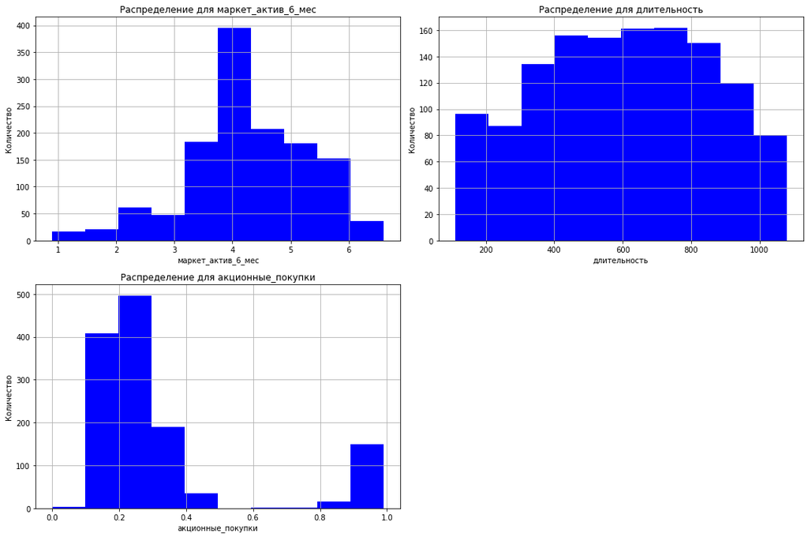

```
Графики распределения для количественных дискретных столбцов (столбчатые диаграммы):
```

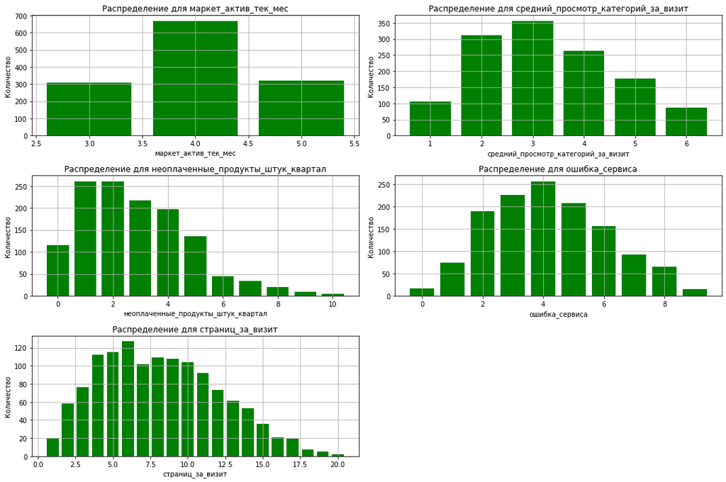

```
Уникальные значения для категориальных столбцов:

Столбец: покупательская_активность
прежний_уровень    802
снизилась          498
Name: покупательская_активность, dtype: int64
Количество уникальных значений: 2

Столбец: тип_сервиса
стандарт     914
премиум      376
стандартт     10
Name: тип_сервиса, dtype: int64
Количество уникальных значений: 3

Столбец: разрешить_сообщать
да     962
нет    338
Name: разрешить_сообщать, dtype: int64
Количество уникальных значений: 2

Столбец: популярная_категория
товары_для_детей                        330
домашний_текстиль                       251
косметика_и_аксесуары                   223
техника_для_красоты_и_здоровья          184
мелкая_бытовая_техника_и_электроника    174
кухонная_посуда                         138
Name: популярная_категория, dtype: int64
Количество уникальных значений: 6

Дубликаты отсутствуют в данных.
```

```python
check_data(market_file)
```

Выполнили проверку, что столбцы и значения в столбцах были стандартизированы (приведены к нижнему регистру, пробелы заменены на "_")

Графики распределения в датасете `market_file` на этом этапе в основном распределены нормально, детальный анализ будет выполнен в пункте исследовательский анализ.

Пропуски при повторном анализе не были обнаружены.

Был обнаружен неявный дубликат в столбце `тип_сервиса`

```python
# Устраним неявный дубликат
market_file['тип_сервиса'] = market_file['тип_сервиса'].replace('стандартт', 'стандарт')
market_file['тип_сервиса'].value_counts()
```

```
стандарт    924
премиум     376
Name: тип_сервиса, dtype: int64
```

```python
# Устраним неявный дубликат
market_file['популярная_категория'] = market_file['популярная_категория'].replace('косметика_и_аксесуары', 'косметика_и_аксессуары')
market_file['популярная_категория'].value_counts()
```

```
товары_для_детей                        330
домашний_текстиль                       251
косметика_и_аксессуары                  223
техника_для_красоты_и_здоровья          184
мелкая_бытовая_техника_и_электроника    174
кухонная_посуда                         138
Name: популярная_категория, dtype: int64
```

**Выполним предобработку датасета `market_money`**

```
Первые строки данных:
```

|  | id | период | выручка |
| --- | --- | --- | --- |
| 0 | 215348 | препредыдущий_месяц | 0.0 |
| 1 | 215348 | текущий_месяц | 3293.1 |
| 2 | 215348 | предыдущий_месяц | 0.0 |
| 3 | 215349 | препредыдущий_месяц | 4472.0 |
| 4 | 215349 | текущий_месяц | 4971.6 |

```
Последние строки данных:
```

|  | id | период | выручка |
| --- | --- | --- | --- |
| 3895 | 216646 | препредыдущий_месяц | 4725.0 |
| 3896 | 216646 | предыдущий_месяц | 4923.0 |
| 3897 | 216647 | предыдущий_месяц | 4720.0 |
| 3898 | 216647 | препредыдущий_месяц | 5183.0 |
| 3899 | 216647 | текущий_месяц | 4448.3 |

```
Размерность данных:
```

```
(3900, 3)
```

```
Информация о типах данных и пропусках:
<class 'pandas.core.frame.DataFrame'>
RangeIndex: 3900 entries, 0 to 3899
Data columns (total 3 columns):
 #   Column   Non-Null Count  Dtype
---  ------   --------------  -----
 0   id       3900 non-null   int64
 1   период   3900 non-null   object
 2   выручка  3900 non-null   float64
dtypes: float64(1), int64(1), object(1)
memory usage: 91.5+ KB
```

```
None
```

```
Пропуски (количество и доля):
Пропуски отсутствуют в данных.

Графики распределения для количественных непрерывных столбцов (гистограммы):
```

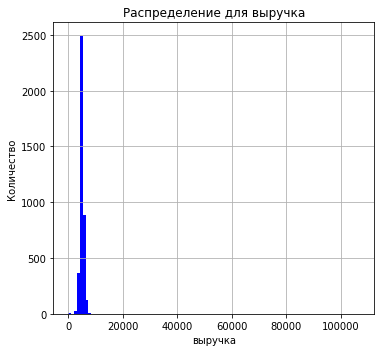

```
Уникальные значения для категориальных столбцов:

Столбец: период
текущий_месяц          1300
предыдущий_месяц       1300
препредыдущий_месяц    1300
Name: период, dtype: int64
Количество уникальных значений: 3

Дубликаты отсутствуют в данных.
```

```python
check_data(market_money, bins=100, figsize=(10, 5))
```

Выполнили проверку, что столбцы и значения в столбцах были стандартизированы (приведены к нижнему регистру, пробелы заменены на "_")

По графикам распределения в датасете `market_money` на этом этапе трудно что-то сказать, детальный анализ будет выполнен в пункте исследовательский анализ.

Пропуски при повторном анализе не были обнаружены.

Дубликаты обнаружены не были.

Категориальные данны распределены равномерно.

**Выполним предобработку датасета `market_time`**

```
Первые строки данных:
```

|  | id | период | минут |
| --- | --- | --- | --- |
| 0 | 215348 | текущий_месяц | 14 |
| 1 | 215348 | предыдцщий_месяц | 13 |
| 2 | 215349 | текущий_месяц | 10 |
| 3 | 215349 | предыдцщий_месяц | 12 |
| 4 | 215350 | текущий_месяц | 13 |

```
Последние строки данных:
```

|  | id | период | минут |
| --- | --- | --- | --- |
| 2595 | 216645 | текущий_месяц | 18 |
| 2596 | 216646 | предыдцщий_месяц | 18 |
| 2597 | 216646 | текущий_месяц | 7 |
| 2598 | 216647 | текущий_месяц | 10 |
| 2599 | 216647 | предыдцщий_месяц | 15 |

```
Размерность данных:
```

```
(2600, 3)
```

```
Информация о типах данных и пропусках:
<class 'pandas.core.frame.DataFrame'>
RangeIndex: 2600 entries, 0 to 2599
Data columns (total 3 columns):
 #   Column  Non-Null Count  Dtype
---  ------  --------------  -----
 0   id      2600 non-null   int64
 1   период  2600 non-null   object
 2   минут   2600 non-null   int64
dtypes: int64(2), object(1)
memory usage: 61.1+ KB
```

```
None
```

```
Пропуски (количество и доля):
Пропуски отсутствуют в данных.

Графики распределения для количественных дискретных столбцов (столбчатые диаграммы):
```

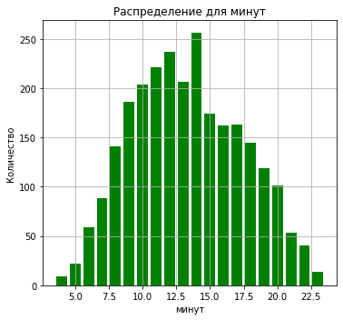

```
Уникальные значения для категориальных столбцов:

Столбец: период
текущий_месяц       1300
предыдцщий_месяц    1300
Name: период, dtype: int64
Количество уникальных значений: 2

Дубликаты отсутствуют в данных.
```

```python
check_data(market_time, figsize=(10, 5))
```

Выполнили проверку, что столбцы и значения в столбцах были стандартизированы (приведены к нижнему регистру, пробелы заменены на "_")

Гистограмма по датасету `market_time` показывает, что данные распределены нормально, детальный анализ будет выполнен в пункте исследовательский анализ.

Пропуски при повторном анализе не были обнаружены.

Дубликаты обнаружены не были.

Обнаружена опечатка в столбце `период`. Категориальные данные распределены равномерно.

```python
# Устраним опечатку
market_time['период'] = market_time['период'].replace('предыдцщий_месяц', 'предыдущий_месяц')
market_time['период'].value_counts()
```

```
текущий_месяц       1300
предыдущий_месяц    1300
Name: период, dtype: int64
```

**Выполним предобработку датасета `money`**

```
Первые строки данных:
```

|  | id | прибыль |
| --- | --- | --- |
| 0 | 215348 | 0.98 |
| 1 | 215349 | 4.16 |
| 2 | 215350 | 3.13 |
| 3 | 215351 | 4.87 |
| 4 | 215352 | 4.21 |

```
Последние строки данных:
```

|  | id | прибыль |
| --- | --- | --- |
| 1295 | 216643 | 4.44 |
| 1296 | 216644 | 6.11 |
| 1297 | 216645 | 3.29 |
| 1298 | 216646 | 4.03 |
| 1299 | 216647 | 3.28 |

```
Размерность данных:
```

```
(1300, 2)
```

```
Информация о типах данных и пропусках:
<class 'pandas.core.frame.DataFrame'>
RangeIndex: 1300 entries, 0 to 1299
Data columns (total 2 columns):
 #   Column   Non-Null Count  Dtype
---  ------   --------------  -----
 0   id       1300 non-null   int64
 1   прибыль  1300 non-null   float64
dtypes: float64(1), int64(1)
memory usage: 20.4 KB
```

```
None
```

```
Пропуски (количество и доля):
Пропуски отсутствуют в данных.

Графики распределения для количественных непрерывных столбцов (гистограммы):
```

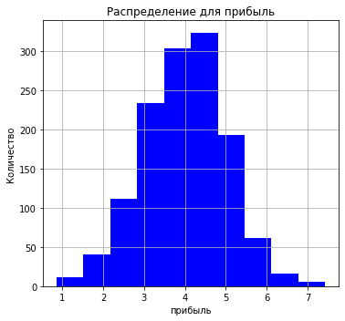

```
Дубликаты отсутствуют в данных.
```

```python
check_data(money, figsize=(10, 5))
```

Выполнили проверку, что столбцы и значения в столбцах были стандартизированы (приведены к нижнему регистру, пробелы заменены на "_")

Гистограмма по датасету `money` показывает, что данные распределены нормально, детальный анализ будет выполнен в пункте исследовательский анализ.

Пропуски при повторном анализе не были обнаружены.

Дубликаты обнаружены не были.

> **Промежуточный итог**: На этапе предобработки данных были выполнены все необходимые шаги для подготовки данных к анализу:
> - Устранены неявные дубликаты и опечатки.
> - Проверены и подтверждены типы данных.
> - Приведены к единому формату названия столбцов и значения в строковых столбцах.
> - Подтверждено отсутствие пропусков и явных дубликатов.
> - Данные полностью готовы для проведения исследовательского анализа и дальнейшего моделирования.

## Исследовательский анализ данных

Содадим функцию для анализа количественных признаков и категориальных признаков.

```python
def number_columns(data, column, bins=50):

    # Описательная статистика
    description = data[column].describe()
    print(f"\n=== Описательная статистика для '{column}' ===")
    print(description)

    # Проверка на выбросы с использованием IQR
    Q1 = data[column].quantile(0.25)
    Q3 = data[column].quantile(0.75)
    IQR = Q3 - Q1
    lower_bound = Q1 - 1.5 * IQR
    upper_bound = Q3 + 1.5 * IQR

    outliers = data[(data[column] < lower_bound) | (data[column] > upper_bound)]
    print(f"\nКоличество выбросов в '{column}': {len(outliers)}")

    # Построение гистограммы и boxplot
    fig, ax = plt.subplots(1, 2, figsize=(15, 6))

    sns.histplot(x=data[column], kde=True, ax=ax[0], bins=bins, color='skyblue')
    ax[0].set_title(f'Гистограмма для {column}')
    ax[0].set_xlabel(column)
    ax[0].set_ylabel('Частота')

    sns.boxplot(x=data[column], ax=ax[1], color='lightgreen')
    ax[1].set_title(f'Boxplot для {column}')
    ax[1].set_xlabel(column)

    plt.tight_layout()
    plt.show()
```

```python
# Выделим функцию для построения графиков
def plot_number_columns(data, column, bins=50):

    # Построение гистограммы и boxplot
    fig, ax = plt.subplots(1, 2, figsize=(15, 6))

    sns.histplot(x=data[column], kde=True, ax=ax[0], bins=bins, color='skyblue')
    ax[0].set_title(f'Гистограмма для {column}')
    ax[0].set_xlabel(column)
    ax[0].set_ylabel('Частота')

    sns.boxplot(x=data[column], ax=ax[1], color='lightgreen')
    ax[1].set_title(f'Boxplot для {column}')
    ax[1].set_xlabel(column)

    plt.tight_layout()
    plt.show()
```

```python
# Функция для исследовательского анализа дискретных количественных признаков
def discrete_columns(data, column):
    # Описательная статистика
    description = data[column].describe()
    print(f"\n=== Описательная статистика для '{column}' ===")
    print(description)

    # Проверка на выбросы с использованием IQR
    Q1 = data[column].quantile(0.25)
    Q3 = data[column].quantile(0.75)
    IQR = Q3 - Q1
    lower_bound = Q1 - 1.5 * IQR
    upper_bound = Q3 + 1.5 * IQR

    outliers = data[(data[column] < lower_bound) | (data[column] > upper_bound)]
    print(f"\nКоличество выбросов в '{column}': {len(outliers)}")

    # Построение графиков на одном полотне
    fig, axes = plt.subplots(1, 2, figsize=(15, 6))

    # Столбчатая диаграмма
    value_counts = data[column].value_counts().sort_index()
    sns.barplot(x=value_counts.index, y=value_counts.values, color='skyblue', ax=axes[0])
    axes[0].set_title(f'Столбчатая диаграмма для {column}')
    axes[0].set_xlabel(column)
    axes[0].set_ylabel('Количество')

    for i in range(len(value_counts)):
        axes[0].text(i, value_counts.values[i], value_counts.values[i], ha='center', va='bottom')

    # Boxplot
    sns.boxplot(x=data[column], color='lightgreen', ax=axes[1])
    axes[1].set_title(f'Boxplot для {column}')
    axes[1].set_xlabel(column)

    plt.tight_layout()
    plt.show()
```

```python
# Выделим функцию для вывода строк с выбросами
def display_outliers(data, column):

    # Проверка на выбросы с использованием IQR
    Q1 = data[column].quantile(0.25)
    Q3 = data[column].quantile(0.75)
    IQR = Q3 - Q1
    lower_bound = Q1 - 1.5 * IQR
    upper_bound = Q3 + 1.5 * IQR

    # Вывод строк с выбросами
    outliers = data[(data[column] < lower_bound) | (data[column] > upper_bound)]
    if not outliers.empty:
        print(f"Выбросы в столбце '{column}':")
        display(outliers)
    else:
        print(f"Выбросы не обнаружены в столбце '{column}'.")

    return outliers
```

Функиця для анализа категориальных признаков.

```python
def plot_categorical_columns(df):
    # Определяем категориальные признаки
    categorical_columns = df.select_dtypes(include=['object', 'category']).columns.tolist()

    # Создаём подграфики
    num_plots = len(categorical_columns)
    rows = (num_plots + 2) // 3
    fig, axs = plt.subplots(rows, 3, figsize=(18, 5 * rows))
    axs = axs.flatten()

    # Генерируем круговые диаграммы
    for i, column in enumerate(categorical_columns):
        # Подсчёт частот категорий
        value_counts = df[column].value_counts()

        # Рисуем круговую диаграмму
        total = value_counts.sum()  # Общее количество записей для столбца
        axs[i].pie(
            value_counts,
            labels=value_counts.index,
            autopct=lambda pct: f'{pct:.1f}% ({int(pct/100.*total)})',  # Проценты и абсолютные значения
            startangle=90
        )
        axs[i].set_title(column)  # Устанавливаем заголовок графика

    # Удаляем пустые оси, если их больше, чем диаграмм
    for j in range(i + 1, len(axs)):
        fig.delaxes(axs[j])

    plt.tight_layout()
    plt.show()
```

**Выполним анализ каждого признака в датасете `market_file`:**

```python
display(market_file.head())
market_file.shape
```

|  | id | покупательская_активность | тип_сервиса | разрешить_сообщать | маркет_актив_6_мес | маркет_актив_тек_мес | длительность | акционные_покупки | популярная_категория | средний_просмотр_категорий_за_визит | неоплаченные_продукты_штук_квартал | ошибка_сервиса | страниц_за_визит |
| --- | --- | --- | --- | --- | --- | --- | --- | --- | --- | --- | --- | --- | --- |
| 0 | 215348 | снизилась | премиум | да | 3.4 | 5 | 121 | 0.00 | товары_для_детей | 6 | 2 | 1 | 5 |
| 1 | 215349 | снизилась | премиум | да | 4.4 | 4 | 819 | 0.75 | товары_для_детей | 4 | 4 | 2 | 5 |
| 2 | 215350 | снизилась | стандарт | нет | 4.9 | 3 | 539 | 0.14 | домашний_текстиль | 5 | 2 | 1 | 5 |
| 3 | 215351 | снизилась | стандарт | да | 3.2 | 5 | 896 | 0.99 | товары_для_детей | 5 | 0 | 6 | 4 |
| 4 | 215352 | снизилась | стандарт | нет | 5.1 | 3 | 1064 | 0.94 | товары_для_детей | 3 | 2 | 3 | 2 |

```
(1300, 13)
```

```
=== Описательная статистика для 'маркет_актив_6_мес' ===
count    1300.000000
mean        4.253769
std         1.014814
min         0.900000
25%         3.700000
50%         4.200000
75%         4.900000
max         6.600000
Name: маркет_актив_6_мес, dtype: float64

Количество выбросов в 'маркет_актив_6_мес': 36
```

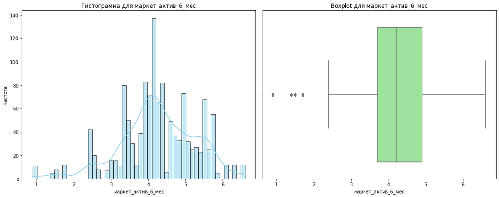

```python
# Выполним анализ признака `маркет_актив_6_мес`
number_columns(market_file, 'маркет_актив_6_мес')
```

Отобразим выбросы в признаке `маркет_актив_6_мес` их 36 штук

```python
display(market_file[market_file['маркет_актив_6_мес'] < 2].head())
market_file[market_file['маркет_актив_6_мес'] < 2].shape[0]
```

|  | id | покупательская_активность | тип_сервиса | разрешить_сообщать | маркет_актив_6_мес | маркет_актив_тек_мес | длительность | акционные_покупки | популярная_категория | средний_просмотр_категорий_за_визит | неоплаченные_продукты_штук_квартал | ошибка_сервиса | страниц_за_визит |
| --- | --- | --- | --- | --- | --- | --- | --- | --- | --- | --- | --- | --- | --- |
| 30 | 215378 | снизилась | стандарт | да | 1.7 | 3 | 488 | 0.39 | техника_для_красоты_и_здоровья | 5 | 1 | 4 | 3 |
| 32 | 215380 | снизилась | премиум | нет | 1.7 | 4 | 637 | 0.94 | техника_для_красоты_и_здоровья | 3 | 2 | 4 | 7 |
| 38 | 215386 | снизилась | стандарт | да | 1.5 | 3 | 495 | 0.98 | домашний_текстиль | 2 | 3 | 7 | 5 |
| 47 | 215395 | снизилась | премиум | да | 1.5 | 5 | 645 | 0.27 | товары_для_детей | 3 | 3 | 6 | 5 |
| 55 | 215403 | снизилась | премиум | да | 1.7 | 5 | 771 | 0.39 | техника_для_красоты_и_здоровья | 1 | 8 | 2 | 5 |

```
36
```

Выбросы в признаке `маркет_актив_6_мес` решено оставить, так как они ими не являются. Наличие их в датасете можно объяснить регистрацией новых пользователей.

```python
market_file['маркет_актив_6_мес'].describe()
```

```
count    1300.000000
mean        4.253769
std         1.014814
min         0.900000
25%         3.700000
50%         4.200000
75%         4.900000
max         6.600000
Name: маркет_актив_6_мес, dtype: float64
```

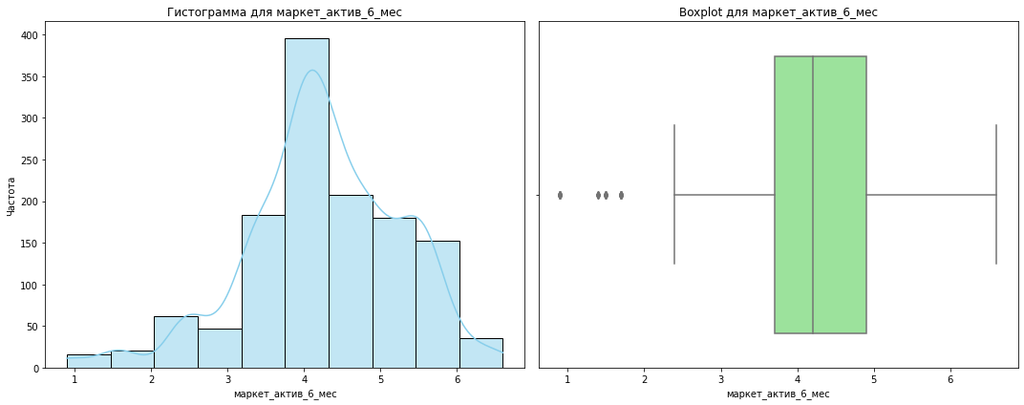

```python
plot_number_columns(market_file, 'маркет_актив_6_мес', bins=10)
```

```
=== Описательная статистика для 'маркет_актив_тек_мес' ===
count    1300.000000
mean        4.011538
std         0.696868
min         3.000000
25%         4.000000
50%         4.000000
75%         4.000000
max         5.000000
Name: маркет_актив_тек_мес, dtype: float64

Количество выбросов в 'маркет_актив_тек_мес': 631
```

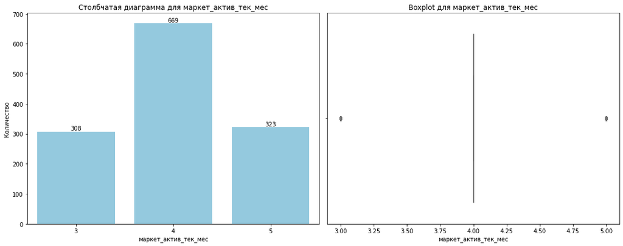

```python
# Выполним анализ признака `маркет_актив_тек_мес`
discrete_columns(market_file, 'маркет_актив_тек_мес')
```

По отношению к признаку `маркет_актив_тек_мес` нет епричина полагать, что в призанк имеет выбросы.

```python
market_file['маркет_актив_тек_мес'].dtype
```

```
dtype('int64')
```

Признак `маркет_актив_тек_мес` имеет дискретный тип данных, рафик имеет 3 независимые группы, но характер распределения выглядит нормальным. Медианное значение равно 4. Наличие пробелов между пиками может говорить о существовании границы между кластерами.

```
=== Описательная статистика для 'длительность' ===
count    1300.000000
mean      601.898462
std       249.856289
min       110.000000
25%       405.500000
50%       606.000000
75%       806.000000
max      1079.000000
Name: длительность, dtype: float64

Количество выбросов в 'длительность': 0
```

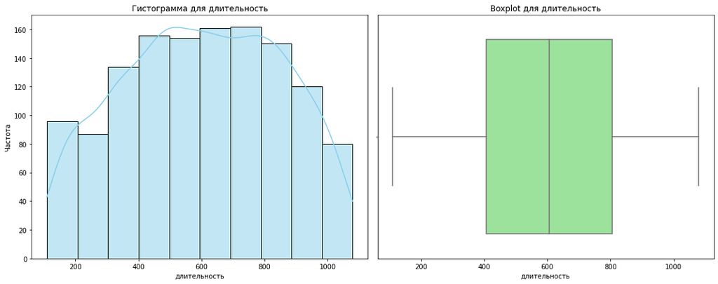

```python
# Выполним анализ признака `длительность`
number_columns(market_file, 'длительность', bins=10)
```

Признак `длительность` - количество дней с момента регистрации покупателя на сайте, имеет характер нормального распределения. Значения признака сосредоточены примерно на одном отрезке по частоте, что может быть связано с особенностями признака. Медианно значение равно 606.

```
=== Описательная статистика для 'акционные_покупки' ===
count    1300.000000
mean        0.319808
std         0.249843
min         0.000000
25%         0.170000
50%         0.240000
75%         0.300000
max         0.990000
Name: акционные_покупки, dtype: float64

Количество выбросов в 'акционные_покупки': 168
```

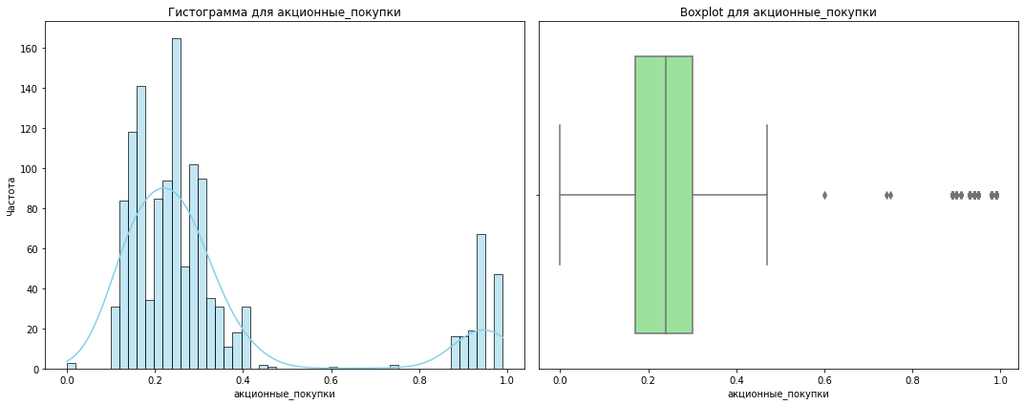

```python
# Выполним анализ признака `акционные_покупки`
number_columns(market_file, 'акционные_покупки')
```

Признак `акционные_покупки` это среднемесячная доля покупок по акции от общего числа покупок за последние 6 месяцев. Поэтому есть причина полагать, что данные находящиеся за верхней границей это не выбросы. Это признак существования границы между кластером. Медианное значение равно 0.24. По графику можно сделать выводы о существовании группы (небольшой, на фоне общего распределения) клиентов, которые покупают товар только при наличии акций.

```
=== Описательная статистика для 'средний_просмотр_категорий_за_визит' ===
count    1300.00000
mean        3.27000
std         1.35535
min         1.00000
25%         2.00000
50%         3.00000
75%         4.00000
max         6.00000
Name: средний_просмотр_категорий_за_визит, dtype: float64

Количество выбросов в 'средний_просмотр_категорий_за_визит': 0
```

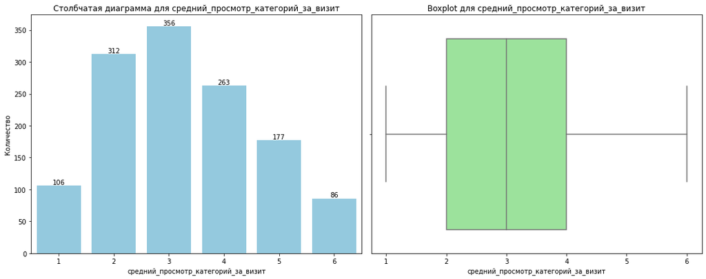

```python
# Выполним анализ признака `средний_просмотр_категорий_за_визит`
discrete_columns(market_file, 'средний_просмотр_категорий_за_визит')
```

Признак `средний_просмотр_категорий_за_визит` имеет дискретный тип данных, график имеет 6 независимые группы, но характер распределения имеет вид нормального. Медианное значение равно 3. Данные в большей степени смещены влево.

```
=== Описательная статистика для 'неоплаченные_продукты_штук_квартал' ===
count    1300.000000
mean        2.840000
std         1.971451
min         0.000000
25%         1.000000
50%         3.000000
75%         4.000000
max        10.000000
Name: неоплаченные_продукты_штук_квартал, dtype: float64

Количество выбросов в 'неоплаченные_продукты_штук_квартал': 14
```

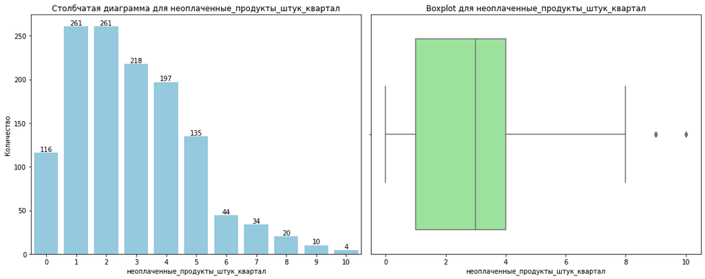

```python
# Выполним анализ признака `неоплаченные_продукты_штук_квартал`
discrete_columns(market_file, 'неоплаченные_продукты_штук_квартал')
```

```python
market_file[market_file['неоплаченные_продукты_штук_квартал'] > 8]
```

|  | id | покупательская_активность | тип_сервиса | разрешить_сообщать | маркет_актив_6_мес | маркет_актив_тек_мес | длительность | акционные_покупки | популярная_категория | средний_просмотр_категорий_за_визит | неоплаченные_продукты_штук_квартал | ошибка_сервиса | страниц_за_визит |
| --- | --- | --- | --- | --- | --- | --- | --- | --- | --- | --- | --- | --- | --- |
| 72 | 215420 | снизилась | стандарт | да | 3.5 | 5 | 449 | 0.35 | домашний_текстиль | 1 | 9 | 2 | 2 |
| 73 | 215421 | снизилась | премиум | нет | 4.0 | 5 | 523 | 0.94 | техника_для_красоты_и_здоровья | 1 | 10 | 7 | 5 |
| 117 | 215465 | снизилась | стандарт | да | 3.5 | 5 | 449 | 0.28 | домашний_текстиль | 1 | 9 | 2 | 2 |
| 118 | 215466 | снизилась | премиум | нет | 2.4 | 5 | 523 | 0.30 | техника_для_красоты_и_здоровья | 1 | 10 | 1 | 4 |
| 176 | 215524 | снизилась | стандарт | да | 3.0 | 3 | 474 | 0.23 | техника_для_красоты_и_здоровья | 1 | 10 | 4 | 2 |
| 186 | 215534 | снизилась | премиум | нет | 4.0 | 4 | 419 | 0.93 | товары_для_детей | 1 | 9 | 3 | 3 |
| 204 | 215552 | снизилась | стандарт | да | 0.9 | 4 | 624 | 0.89 | косметика_и_аксессуары | 1 | 9 | 5 | 1 |
| 216 | 215564 | снизилась | стандарт | нет | 3.9 | 3 | 618 | 0.24 | техника_для_красоты_и_здоровья | 2 | 10 | 3 | 5 |
| 246 | 215594 | снизилась | стандарт | да | 4.2 | 4 | 627 | 0.90 | товары_для_детей | 6 | 9 | 5 | 8 |
| 251 | 215599 | снизилась | стандарт | да | 3.4 | 4 | 716 | 0.28 | домашний_текстиль | 2 | 9 | 4 | 6 |
| 307 | 215655 | снизилась | стандарт | да | 3.9 | 4 | 819 | 0.94 | товары_для_детей | 1 | 9 | 4 | 2 |
| 320 | 215668 | снизилась | премиум | да | 4.4 | 4 | 343 | 0.94 | товары_для_детей | 2 | 9 | 2 | 2 |
| 348 | 215696 | снизилась | премиум | да | 3.4 | 3 | 384 | 0.98 | кухонная_посуда | 1 | 9 | 4 | 3 |
| 350 | 215698 | снизилась | стандарт | да | 3.5 | 4 | 685 | 0.89 | техника_для_красоты_и_здоровья | 2 | 9 | 3 | 3 |

Распределение признака `неоплаченные_продукты_штук_квартал` стремится к нормальному. В основанном данные распределены в сторону < 3. Медианное значение равно 3. Было найдено 14 выбросов, которые было решено оставить, из-за небольшого количества, да и выведенные данные не говорят об аномальности этих выбросов.

```
=== Описательная статистика для 'ошибка_сервиса' ===
count    1300.000000
mean        4.185385
std         1.955298
min         0.000000
25%         3.000000
50%         4.000000
75%         6.000000
max         9.000000
Name: ошибка_сервиса, dtype: float64

Количество выбросов в 'ошибка_сервиса': 0
```

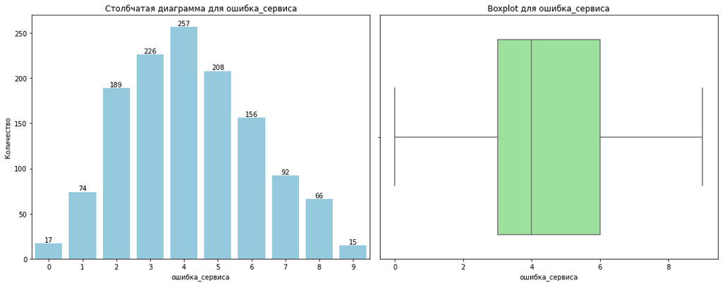

```python
# Выполним анализ признака `ошибка_сервиса`
discrete_columns(market_file, 'ошибка_сервиса')
```

Распределение признака `ошибка_сервиса` нормальное. Медиананое значение находится на отметке 4.

```
=== Описательная статистика для 'страниц_за_визит' ===
count    1300.000000
mean        8.176923
std         3.978126
min         1.000000
25%         5.000000
50%         8.000000
75%        11.000000
max        20.000000
Name: страниц_за_визит, dtype: float64

Количество выбросов в 'страниц_за_визит': 0
```

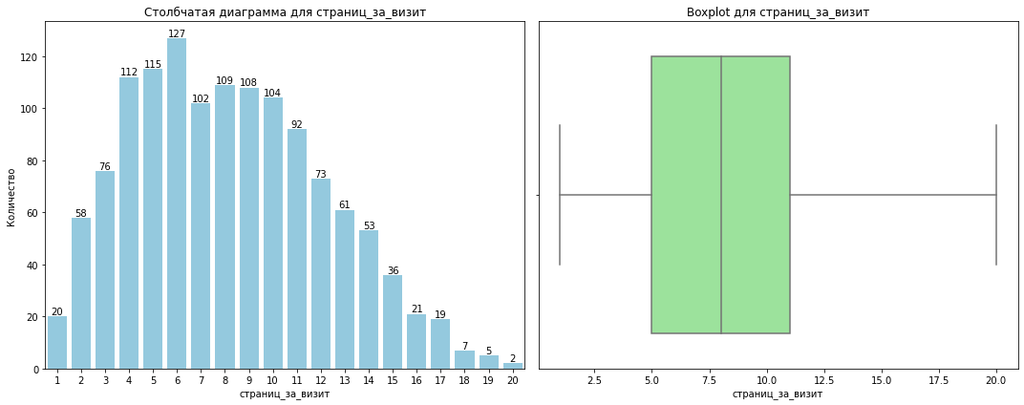

```python
# Выполним анализ признака `страниц_за_визит`
discrete_columns(market_file, 'страниц_за_визит')
```

Теперь иследуем категориальные признаки.

```python
market_file.head()
```

|  | id | покупательская_активность | тип_сервиса | разрешить_сообщать | маркет_актив_6_мес | маркет_актив_тек_мес | длительность | акционные_покупки | популярная_категория | средний_просмотр_категорий_за_визит | неоплаченные_продукты_штук_квартал | ошибка_сервиса | страниц_за_визит |
| --- | --- | --- | --- | --- | --- | --- | --- | --- | --- | --- | --- | --- | --- |
| 0 | 215348 | снизилась | премиум | да | 3.4 | 5 | 121 | 0.00 | товары_для_детей | 6 | 2 | 1 | 5 |
| 1 | 215349 | снизилась | премиум | да | 4.4 | 4 | 819 | 0.75 | товары_для_детей | 4 | 4 | 2 | 5 |
| 2 | 215350 | снизилась | стандарт | нет | 4.9 | 3 | 539 | 0.14 | домашний_текстиль | 5 | 2 | 1 | 5 |
| 3 | 215351 | снизилась | стандарт | да | 3.2 | 5 | 896 | 0.99 | товары_для_детей | 5 | 0 | 6 | 4 |
| 4 | 215352 | снизилась | стандарт | нет | 5.1 | 3 | 1064 | 0.94 | товары_для_детей | 3 | 2 | 3 | 2 |

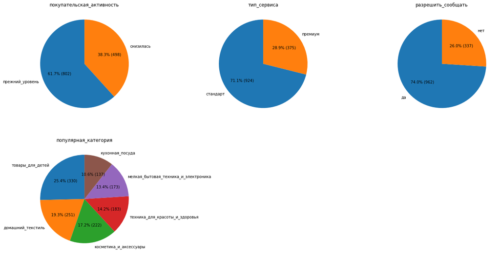

```python
plot_categorical_columns(market_file)
```

- `покупательская_активность`: Целевой признак, по распределению видно, что присутствует дисбаланс классов. Это нужно будет учитывать при построении модели. Распределение целевого признака распределена в большую сторону к прежнему уровню.
- `тип_сервиса`: Признак довольно сильно распределен строну стандартного сервиса - 71.1%, что довольно очевидно.
- `разрешить_сообщать`: Большинство пользователей магазина согласны получать рассылку - 74%
- `популярная_категория`: Самая популярная категория товара у пользователей, это товары для детей 25.4%. Самой не популярной категорией является кухонная посуда.

**Выполним анализ каждого признака в датасете `market_money`:**

```python
market_money.head()
```

|  | id | период | выручка |
| --- | --- | --- | --- |
| 0 | 215348 | препредыдущий_месяц | 0.0 |
| 1 | 215348 | текущий_месяц | 3293.1 |
| 2 | 215348 | предыдущий_месяц | 0.0 |
| 3 | 215349 | препредыдущий_месяц | 4472.0 |
| 4 | 215349 | текущий_месяц | 4971.6 |

```
=== Описательная статистика для 'выручка' ===
count      3900.000000
mean       5025.696051
std        1777.704104
min           0.000000
25%        4590.150000
50%        4957.500000
75%        5363.000000
max      106862.200000
Name: выручка, dtype: float64

Количество выбросов в 'выручка': 175
```

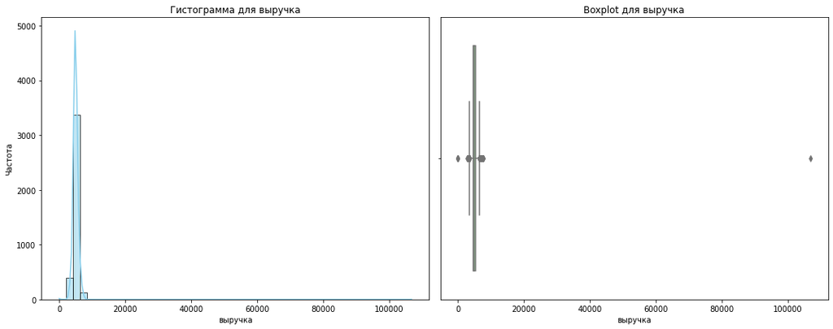

```python
# Выполним анализ признака `выручка`
number_columns(market_money, 'выручка')
```

Отобразим выбросы в признаке `выручка'

```python
display(market_money[market_money['выручка'] > 20000])
market_money[market_money['выручка'] < 1000]
```

|  | id | период | выручка |
| --- | --- | --- | --- |
| 98 | 215380 | текущий_месяц | 106862.2 |

|  | id | период | выручка |
| --- | --- | --- | --- |
| 0 | 215348 | препредыдущий_месяц | 0.0 |
| 2 | 215348 | предыдущий_месяц | 0.0 |
| 28 | 215357 | препредыдущий_месяц | 0.0 |
| 29 | 215357 | предыдущий_месяц | 0.0 |
| 34 | 215359 | предыдущий_месяц | 0.0 |
| 35 | 215359 | препредыдущий_месяц | 0.0 |

Удалим аномалию и пользователей выручка от которых равно 0. Это выполняется т.к. компания заинтересована в удержании постоянных клиентов.

Удалим данных пользователей из других датафреймов тоже

```python
ids_to_remove = [215380, 215348, 215357, 215359]

# Удаление строк по id
market_file = market_file[~market_file['id'].isin(ids_to_remove)]
market_money = market_money[~market_money['id'].isin(ids_to_remove)]
market_time = market_time[~market_time['id'].isin(ids_to_remove)]
money = money[~money['id'].isin(ids_to_remove)]

display(market_file.shape)
display(market_money.shape)
display(market_time.shape)
money.shape
```

```
(1296, 13)
```

```
(3888, 3)
```

```
(2592, 3)
```

```
(1296, 2)
```

Построим график еще раз

```
=== Описательная статистика для 'выручка' ===
count    3888.000000
mean     5007.255658
std       679.193461
min      2758.700000
25%      4591.950000
50%      4959.000000
75%      5363.000000
max      7799.400000
Name: выручка, dtype: float64

Количество выбросов в 'выручка': 168
```

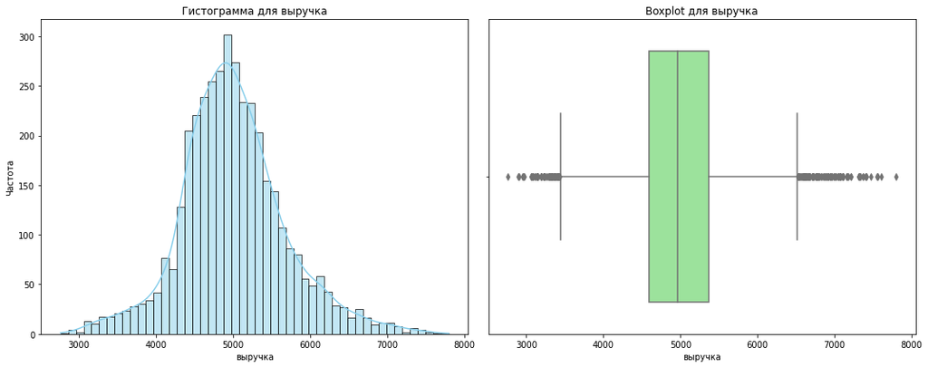

```python
number_columns(market_money, 'выручка')
```

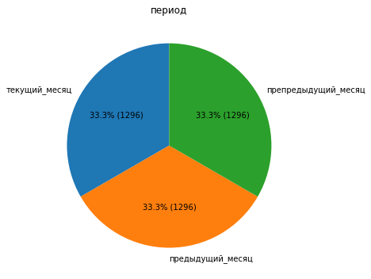

```python
# Выполним анализ категориального признака в датасете
plot_categorical_columns(market_money)
```

Категориальный признак `период` равно распределен.

Выполним анализ каждого признака в датасете `market_time`:

```python
market_time.head()
```

|  | id | период | минут |
| --- | --- | --- | --- |
| 2 | 215349 | текущий_месяц | 10 |
| 3 | 215349 | предыдущий_месяц | 12 |
| 4 | 215350 | текущий_месяц | 13 |
| 5 | 215350 | предыдущий_месяц | 8 |
| 6 | 215351 | текущий_месяц | 13 |

```
=== Описательная статистика для 'минут' ===
count    2592.000000
mean       13.340664
std         4.083469
min         4.000000
25%        10.000000
50%        13.000000
75%        16.000000
max        23.000000
Name: минут, dtype: float64

Количество выбросов в 'минут': 0
```

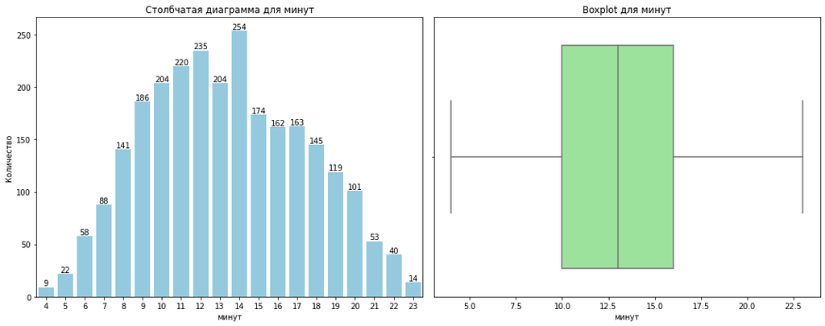

```python
# Выполним анализ признака `минут`
discrete_columns(market_time, 'минут')
```

По гистограмме можно прийти к выводу, что данные в признаке `минут` распределены нормально, пользователь в среднем проводит на сайте примерно 13 минут, выбросы отсутствуют.

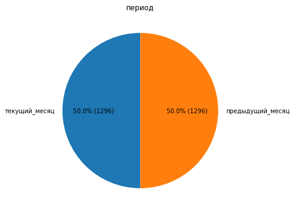

```python
# Выполним анализ категориального признака в датасете
plot_categorical_columns(market_time)
```

Категориальный признак `период` во время которого зафиксировано общее время, равномерно распределен.

Выполним анализ признака в датасете `money`:

```python
money.head()
```

|  | id | прибыль |
| --- | --- | --- |
| 1 | 215349 | 4.16 |
| 2 | 215350 | 3.13 |
| 3 | 215351 | 4.87 |
| 4 | 215352 | 4.21 |
| 5 | 215353 | 3.95 |

```
=== Описательная статистика для 'прибыль' ===
count    1296.000000
mean        3.997701
std         1.011198
min         0.860000
25%         3.300000
50%         4.045000
75%         4.670000
max         7.430000
Name: прибыль, dtype: float64

Количество выбросов в 'прибыль': 11
```

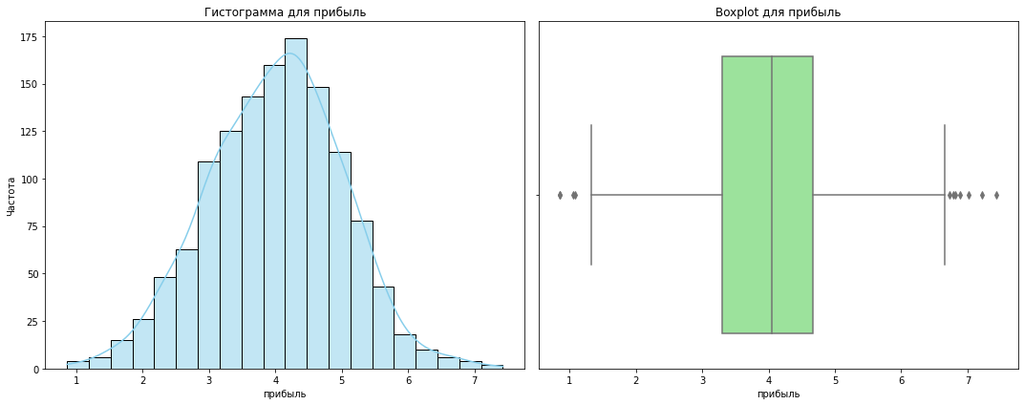

```python
number_columns(money, 'прибыль', bins=20)
```

```python
outliers = display_outliers(money, 'прибыль')
```

```
Выбросы в столбце 'прибыль':
```

|  | id | прибыль |
| --- | --- | --- |
| 52 | 215400 | 6.73 |
| 53 | 215401 | 7.43 |
| 182 | 215530 | 1.06 |
| 215 | 215563 | 6.88 |
| 637 | 215985 | 6.78 |
| 774 | 216122 | 0.86 |
| 817 | 216165 | 7.02 |
| 920 | 216268 | 6.81 |
| 938 | 216286 | 1.08 |
| 976 | 216324 | 0.86 |
| 1026 | 216374 | 7.21 |

Данный признак `прибыль` содежрит информацию, о том какую прибыль получает магазин от продаж каждому покупателю за последние 3 месяца.

Прибыль в моем понимании это выручка - все издержки = прибыль. Следуя этой мысли можно прийти к выводу, что признак прибыль измеряется в тысячах. В этом случае прибыль в размере 860 рублей имеет место быть и это не будет являться выбросом.

> **Промежуточные выводы**

> **`market_time`**
> - **Количественный признак:**
>   - Признак `минут`: Распределение близко к нормальному, медиана = 13 минут. Выбросы отсутствуют.
> - **Категориальный признак:**
>   - Признак `период`: Равномерно распределен между категориями "текущий_месяц" и "предыдущий_месяц".

> **Общий вывод по исследовательскому анализу данных:**

## Объединение таблиц

Для построения модели следует использовать данные о пользователях которые были активны в течение последних трёх месяцев. Исключение пользователей, которые не проявляли активность последние 3 месяца, позволит нам избежать уменьшения качества модели.

```python
display(market_file.head())
market_file.shape
```

|  | id | покупательская_активность | тип_сервиса | разрешить_сообщать | маркет_актив_6_мес | маркет_актив_тек_мес | длительность | акционные_покупки | популярная_категория | средний_просмотр_категорий_за_визит | неоплаченные_продукты_штук_квартал | ошибка_сервиса | страниц_за_визит |
| --- | --- | --- | --- | --- | --- | --- | --- | --- | --- | --- | --- | --- | --- |
| 1 | 215349 | снизилась | премиум | да | 4.4 | 4 | 819 | 0.75 | товары_для_детей | 4 | 4 | 2 | 5 |
| 2 | 215350 | снизилась | стандарт | нет | 4.9 | 3 | 539 | 0.14 | домашний_текстиль | 5 | 2 | 1 | 5 |
| 3 | 215351 | снизилась | стандарт | да | 3.2 | 5 | 896 | 0.99 | товары_для_детей | 5 | 0 | 6 | 4 |
| 4 | 215352 | снизилась | стандарт | нет | 5.1 | 3 | 1064 | 0.94 | товары_для_детей | 3 | 2 | 3 | 2 |
| 5 | 215353 | снизилась | стандарт | да | 3.3 | 4 | 762 | 0.26 | домашний_текстиль | 4 | 1 | 1 | 4 |

```
(1296, 13)
```

Выполним объединение таблиц `market_file`, `market_money`, `market_time`.

```python
# Преобразуем таблицу market_money
market_money_pivot = (market_money.pivot_table(
        index='id',
        columns='период',
        values='выручка',
        aggfunc='sum'
    ).rename(columns={
        'текущий_месяц': 'выручка_тек',
        'предыдущий_месяц': 'выручка_пред',
        'препредыдущий_месяц': 'выручка_препред'
    }).reset_index()
)

# Проверяем результат
display(market_money_pivot.head())
market_money_pivot.shape
```

| период | id | выручка_пред | выручка_препред | выручка_тек |
| --- | --- | --- | --- | --- |
| 0 | 215349 | 5216.0 | 4472.0 | 4971.6 |
| 1 | 215350 | 5457.5 | 4826.0 | 5058.4 |
| 2 | 215351 | 6158.0 | 4793.0 | 6610.4 |
| 3 | 215352 | 5807.5 | 4594.0 | 5872.5 |
| 4 | 215353 | 4738.5 | 5124.0 | 5388.5 |

```
(1296, 4)
```

```python
# Преобразуем таблицу market_time
market_time_pivot = (market_time.pivot_table(
        index='id',
        columns='период',
        values='минут',
        aggfunc='sum'
    ).rename(columns={
        'текущий_месяц': 'минут_тек',
        'предыдущий_месяц': 'минут_пред'
    }).reset_index()
)

# Проверяем результат
display(market_time_pivot.head())
market_time_pivot.shape
```

| период | id | минут_пред | минут_тек |
| --- | --- | --- | --- |
| 0 | 215349 | 12 | 10 |
| 1 | 215350 | 8 | 13 |
| 2 | 215351 | 11 | 13 |
| 3 | 215352 | 8 | 11 |
| 4 | 215353 | 10 | 10 |

```
(1296, 3)
```

```python
# Объединяем таблицы
market_data = (market_file
    .merge(market_money_pivot, how='inner', on='id')
    .merge(market_time_pivot, how='inner', on='id')
)

# Проверяем результат
display(market_data.head())
market_data.shape
```

|  | id | покупательская_активность | тип_сервиса | разрешить_сообщать | маркет_актив_6_мес | маркет_актив_тек_мес | длительность | акционные_покупки | популярная_категория | средний_просмотр_категорий_за_визит | неоплаченные_продукты_штук_квартал | ошибка_сервиса | страниц_за_визит | выручка_пред | выручка_препред | выручка_тек | минут_пред | минут_тек |
| --- | --- | --- | --- | --- | --- | --- | --- | --- | --- | --- | --- | --- | --- | --- | --- | --- | --- | --- |
| 0 | 215349 | снизилась | премиум | да | 4.4 | 4 | 819 | 0.75 | товары_для_детей | 4 | 4 | 2 | 5 | 5216.0 | 4472.0 | 4971.6 | 12 | 10 |
| 1 | 215350 | снизилась | стандарт | нет | 4.9 | 3 | 539 | 0.14 | домашний_текстиль | 5 | 2 | 1 | 5 | 5457.5 | 4826.0 | 5058.4 | 8 | 13 |
| 2 | 215351 | снизилась | стандарт | да | 3.2 | 5 | 896 | 0.99 | товары_для_детей | 5 | 0 | 6 | 4 | 6158.0 | 4793.0 | 6610.4 | 11 | 13 |
| 3 | 215352 | снизилась | стандарт | нет | 5.1 | 3 | 1064 | 0.94 | товары_для_детей | 3 | 2 | 3 | 2 | 5807.5 | 4594.0 | 5872.5 | 8 | 11 |
| 4 | 215353 | снизилась | стандарт | да | 3.3 | 4 | 762 | 0.26 | домашний_текстиль | 4 | 1 | 1 | 4 | 4738.5 | 5124.0 | 5388.5 | 10 | 10 |

```
(1296, 18)
```

Проверим весь датасет на наличие пропусков.

```python
market_data.isna().sum()
```

```
id                                     0
покупательская_активность              0
тип_сервиса                            0
разрешить_сообщать                     0
маркет_актив_6_мес                     0
маркет_актив_тек_мес                   0
длительность                           0
акционные_покупки                      0
популярная_категория                   0
средний_просмотр_категорий_за_визит    0
неоплаченные_продукты_штук_квартал     0
ошибка_сервиса                         0
страниц_за_визит                       0
выручка_пред                           0
выручка_препред                        0
выручка_тек                            0
минут_пред                             0
минут_тек                              0
dtype: int64
```

> **Промежуточные выводы**

> Объединение данных прошло успешно, пропуски после объединения не обнаружены. Были созданы отдельные столбцы для каждого периода из датасетов `market_time` и `market_money`.

## Корреляционный анализ

Посмтроим матрицу корреляция и определим взяимосвязь между всеми признаками.

```python
market_data.describe()
```

|  | id | маркет_актив_6_мес | маркет_актив_тек_мес | длительность | акционные_покупки | средний_просмотр_категорий_за_визит | неоплаченные_продукты_штук_квартал | ошибка_сервиса | страниц_за_визит | выручка_пред | выручка_препред | выручка_тек | минут_пред | минут_тек |
| --- | --- | --- | --- | --- | --- | --- | --- | --- | --- | --- | --- | --- | --- | --- |
| count | 1296.000000 | 1296.000000 | 1296.000000 | 1296.000000 | 1296.000000 | 1296.000000 | 1296.000000 | 1296.000000 | 1296.000000 | 1296.000000 | 1296.000000 | 1296.000000 | 1296.000000 | 1296.000000 |
| mean | 215999.464506 | 4.256404 | 4.009259 | 602.967593 | 0.320069 | 3.267747 | 2.841821 | 4.184414 | 8.187500 | 4947.468750 | 4836.202160 | 5238.096065 | 13.470679 | 13.210648 |
| std | 374.327860 | 1.013525 | 0.696316 | 249.195823 | 0.249159 | 1.355125 | 1.974074 | 1.951719 | 3.978459 | 700.797239 | 333.514091 | 834.318717 | 3.937630 | 4.221794 |
| min | 215349.000000 | 0.900000 | 3.000000 | 121.000000 | 0.110000 | 1.000000 | 0.000000 | 0.000000 | 1.000000 | 2890.000000 | 4098.000000 | 2758.700000 | 5.000000 | 4.000000 |
| 25% | 215675.750000 | 3.700000 | 4.000000 | 409.500000 | 0.170000 | 2.000000 | 1.000000 | 3.000000 | 5.000000 | 4498.125000 | 4584.500000 | 4706.050000 | 10.750000 | 10.000000 |
| 50% | 215999.500000 | 4.200000 | 4.000000 | 606.500000 | 0.240000 | 3.000000 | 3.000000 | 4.000000 | 8.000000 | 5005.500000 | 4810.500000 | 5179.950000 | 13.000000 | 13.000000 |
| 75% | 216323.250000 | 4.900000 | 4.000000 | 806.250000 | 0.300000 | 4.000000 | 4.000000 | 6.000000 | 11.000000 | 5405.625000 | 5056.000000 | 5759.275000 | 17.000000 | 16.000000 |
| max | 216647.000000 | 6.600000 | 5.000000 | 1079.000000 | 0.990000 | 6.000000 | 10.000000 | 9.000000 | 20.000000 | 6869.500000 | 5663.000000 | 7799.400000 | 23.000000 | 23.000000 |

```python
market_data.info()
```

```
<class 'pandas.core.frame.DataFrame'>
Int64Index: 1296 entries, 0 to 1295
Data columns (total 18 columns):
 #   Column                               Non-Null Count  Dtype
---  ------                               --------------  -----
 0   id                                   1296 non-null   int64
 1   покупательская_активность            1296 non-null   object
 2   тип_сервиса                          1296 non-null   object
 3   разрешить_сообщать                   1296 non-null   object
 4   маркет_актив_6_мес                   1296 non-null   float64
 5   маркет_актив_тек_мес                 1296 non-null   int64
 6   длительность                         1296 non-null   int64
 7   акционные_покупки                    1296 non-null   float64
 8   популярная_категория                 1296 non-null   object
 9   средний_просмотр_категорий_за_визит  1296 non-null   int64
 10  неоплаченные_продукты_штук_квартал   1296 non-null   int64
 11  ошибка_сервиса                       1296 non-null   int64
 12  страниц_за_визит                     1296 non-null   int64
 13  выручка_пред                         1296 non-null   float64
 14  выручка_препред                      1296 non-null   float64
 15  выручка_тек                          1296 non-null   float64
 16  минут_пред                           1296 non-null   int64
 17  минут_тек                            1296 non-null   int64
dtypes: float64(5), int64(9), object(4)
memory usage: 192.4+ KB
```

```python
# Избавимся от столбца `id` и всех дискретных и категориальных столбцов
corr_heatmap = [col for col in market_data.columns
                  if col not in ['id', 'покупательская_активность',
                                 'маркет_актив_тек_мес', 'тип_сервиса',
                                 'разрешить_сообщать', 'популярная_категория',
                                 'средний_просмотр_категорий_за_визит',
                                 'неоплаченные_продукты_штук_квартал',
                                 'ошибка_сервиса', 'страниц_за_визит',
                                 'минут_пред', 'минут_тек']]
corr_heatmap
```

```
['маркет_актив_6_мес',
 'длительность',
 'акционные_покупки',
 'выручка_пред',
 'выручка_препред',
 'выручка_тек']
```

```python
# Создадим копию датасета, чтобы удалить 'id'

market_data_corr = market_data.copy().drop('id', axis=1)
market_data_corr.head()
```

|  | покупательская_активность | тип_сервиса | разрешить_сообщать | маркет_актив_6_мес | маркет_актив_тек_мес | длительность | акционные_покупки | популярная_категория | средний_просмотр_категорий_за_визит | неоплаченные_продукты_штук_квартал | ошибка_сервиса | страниц_за_визит | выручка_пред | выручка_препред | выручка_тек | минут_пред | минут_тек |
| --- | --- | --- | --- | --- | --- | --- | --- | --- | --- | --- | --- | --- | --- | --- | --- | --- | --- |
| 0 | снизилась | премиум | да | 4.4 | 4 | 819 | 0.75 | товары_для_детей | 4 | 4 | 2 | 5 | 5216.0 | 4472.0 | 4971.6 | 12 | 10 |
| 1 | снизилась | стандарт | нет | 4.9 | 3 | 539 | 0.14 | домашний_текстиль | 5 | 2 | 1 | 5 | 5457.5 | 4826.0 | 5058.4 | 8 | 13 |
| 2 | снизилась | стандарт | да | 3.2 | 5 | 896 | 0.99 | товары_для_детей | 5 | 0 | 6 | 4 | 6158.0 | 4793.0 | 6610.4 | 11 | 13 |
| 3 | снизилась | стандарт | нет | 5.1 | 3 | 1064 | 0.94 | товары_для_детей | 3 | 2 | 3 | 2 | 5807.5 | 4594.0 | 5872.5 | 8 | 11 |
| 4 | снизилась | стандарт | да | 3.3 | 4 | 762 | 0.26 | домашний_текстиль | 4 | 1 | 1 | 4 | 4738.5 | 5124.0 | 5388.5 | 10 | 10 |

Построим матрицу корреляцию используя функцию `phik_matrix()`. Данный метод в каком то смысле универсальный, так как работает с категориальными и с количественными данными. К тому же в датасете присутствуют выбросы, которые могли исказить результаты корреляции Пирсона.

```
['id', 'маркет_актив_6_мес', 'маркет_актив_тек_мес', 'длительность', 'акционные_покупки', 'средний_просмотр_категорий_за_визит', 'неоплаченные_продукты_штук_квартал', 'ошибка_сервиса', 'страниц_за_визит', 'выручка_пред', 'выручка_препред', 'выручка_тек', 'минут_пред', 'минут_тек']
```

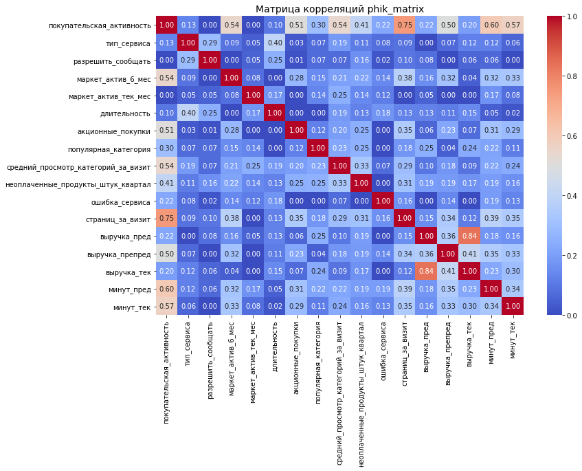

```python
# Визуализируем матрицу корреляции
interval_cols = market_data.select_dtypes(include='number').columns.tolist()
print(interval_cols)

plt.figure(figsize=(12, 8))
sns.heatmap(market_data_corr.phik_matrix(interval_cols=corr_heatmap), annot=True, fmt='.2f', cmap="coolwarm")
plt.title('Матрица корреляций phik_matrix', fontsize=14)
plt.show()
```

```python
# Определим признаки, которые наиболее сильно коррелируют с покупательская_активность.
market_data_corr.phik_matrix(interval_cols=corr_heatmap)['покупательская_активность'].sort_values(
                                                                                                ascending=False).round(2)
```

```
покупательская_активность              1.00
страниц_за_визит                       0.75
минут_пред                             0.60
минут_тек                              0.57
маркет_актив_6_мес                     0.54
средний_просмотр_категорий_за_визит    0.54
акционные_покупки                      0.51
выручка_препред                        0.50
неоплаченные_продукты_штук_квартал     0.41
популярная_категория                   0.30
выручка_пред                           0.22
ошибка_сервиса                         0.22
выручка_тек                            0.20
тип_сервиса                            0.13
длительность                           0.10
маркет_актив_тек_мес                   0.00
разрешить_сообщать                     0.00
Name: покупательская_активность, dtype: float64
```

Целевой признак `покупательская_активность` имет довольно высокую корреляцию с признаком `страниц_за_визит - 0.75`, этого можно было ожидать, т. к. чем больше страниц покупатель просматривает, тем больше вероятность покупки товара в магазине. Целевой признак имеет заментную корреляцию с признаком с признаками `минут_пред - 0.60`, `минут_тек - 0.57`, `маркет_актив_6_мес - 0.54` `средний_просмотр_категорий_за_визит - 0.54`, `неоплаченные_продукты_штук_квартал - 0.41`, `акционные_покупки - 0.51` `выручка_препред - 0.50` и умеренную корреляцию с признаками `популярная_категория - 0.30`, `выручка_пред - 0.22`, `выручка_тек 0.20`. С остальными признаками целевой признак имеет слаюбую корреляцию или вообще практически не имеет.

```python
market_data = market_data.drop(['длительность', 'ошибка_сервиса',
                                'маркет_актив_тек_мес', 'разрешить_сообщать', 'выручка_тек', 'минут_тек'], axis=1)
market_data.head()
```

|  | id | покупательская_активность | тип_сервиса | маркет_актив_6_мес | акционные_покупки | популярная_категория | средний_просмотр_категорий_за_визит | неоплаченные_продукты_штук_квартал | страниц_за_визит | выручка_пред | выручка_препред | минут_пред |
| --- | --- | --- | --- | --- | --- | --- | --- | --- | --- | --- | --- | --- |
| 0 | 215349 | снизилась | премиум | 4.4 | 0.75 | товары_для_детей | 4 | 4 | 5 | 5216.0 | 4472.0 | 12 |
| 1 | 215350 | снизилась | стандарт | 4.9 | 0.14 | домашний_текстиль | 5 | 2 | 5 | 5457.5 | 4826.0 | 8 |
| 2 | 215351 | снизилась | стандарт | 3.2 | 0.99 | товары_для_детей | 5 | 0 | 4 | 6158.0 | 4793.0 | 11 |
| 3 | 215352 | снизилась | стандарт | 5.1 | 0.94 | товары_для_детей | 3 | 2 | 2 | 5807.5 | 4594.0 | 8 |
| 4 | 215353 | снизилась | стандарт | 3.3 | 0.26 | домашний_текстиль | 4 | 1 | 4 | 4738.5 | 5124.0 | 10 |

Визуализируем матрицу после удаления столбов

```python
# Создадим копию датасета, чтобы удалить 'id'

market_data_corr = market_data.copy().drop('id', axis=1)
market_data_corr.head()
```

|  | покупательская_активность | тип_сервиса | маркет_актив_6_мес | акционные_покупки | популярная_категория | средний_просмотр_категорий_за_визит | неоплаченные_продукты_штук_квартал | страниц_за_визит | выручка_пред | выручка_препред | минут_пред |
| --- | --- | --- | --- | --- | --- | --- | --- | --- | --- | --- | --- |
| 0 | снизилась | премиум | 4.4 | 0.75 | товары_для_детей | 4 | 4 | 5 | 5216.0 | 4472.0 | 12 |
| 1 | снизилась | стандарт | 4.9 | 0.14 | домашний_текстиль | 5 | 2 | 5 | 5457.5 | 4826.0 | 8 |
| 2 | снизилась | стандарт | 3.2 | 0.99 | товары_для_детей | 5 | 0 | 4 | 6158.0 | 4793.0 | 11 |
| 3 | снизилась | стандарт | 5.1 | 0.94 | товары_для_детей | 3 | 2 | 2 | 5807.5 | 4594.0 | 8 |
| 4 | снизилась | стандарт | 3.3 | 0.26 | домашний_текстиль | 4 | 1 | 4 | 4738.5 | 5124.0 | 10 |

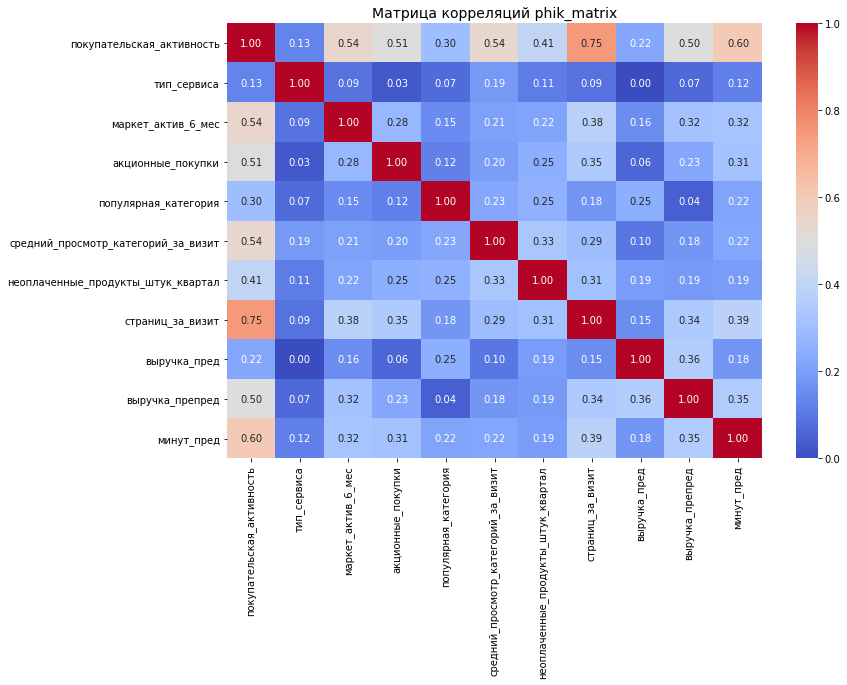

```python
# Визуализируем матрицу корреляции
plt.figure(figsize=(12, 8))
sns.heatmap(market_data_corr.phik_matrix(interval_cols=corr_heatmap), annot=True, fmt='.2f', cmap="coolwarm")
plt.title('Матрица корреляций phik_matrix', fontsize=14)
plt.show()
```

> **Промежуточные выводы**

> На этапе корреляционного анализа были выполнены все необходимые шаги для подготовки данных к обучению моделей:
> - Удалены слабо коррелирующие признаки: `длительность`, `маркет_актив_тек_мес` и `разрешить_сообщать`.
> - Устранена утечка (мультиколлинеарность) данных между признаками `выручка_пред` и `выручка_тек`.
> - Выявлены ключевые признаки, влияющие на целевой признак.
> - Данные полностью готовы для использования в пайплайнах и дальнейшего моделирования.

## Использование пайплайнов

Выполним подготовку данных пред обучением модели.

### Подготовка данных

```python
# Разделяем данные на обучающую и тестовую выборки
X = market_data.drop(['id', 'покупательская_активность'], axis=1)
y = market_data['покупательская_активность']

X_train, X_test, y_train, y_test = train_test_split(
    X, y, random_state=RANDOM_STATE, stratify=y
)
```

```python
print(X_train.shape)
print(X_test.shape)
print(y_train.shape)
print(y_test.shape)
```

```
(972, 10)
(324, 10)
(972,)
(324,)
```

Выполним кодировку целевого признака с помощью `LabelEncoder`.

```python
label_encoder = LabelEncoder()
y_train = label_encoder.fit_transform(y_train)
y_test = label_encoder.transform(y_test)
```

Создадим списки с признаками для будущего кодирования и масштабирования

```python
X_train.head()
```

|  | тип_сервиса | маркет_актив_6_мес | акционные_покупки | популярная_категория | средний_просмотр_категорий_за_визит | неоплаченные_продукты_штук_квартал | страниц_за_визит | выручка_пред | выручка_препред | минут_пред |
| --- | --- | --- | --- | --- | --- | --- | --- | --- | --- | --- |
| 506 | стандарт | 5.5 | 0.15 | мелкая_бытовая_техника_и_электроника | 2 | 4 | 16 | 5170.5 | 4347.0 | 20 |
| 10 | стандарт | 5.1 | 0.23 | техника_для_красоты_и_здоровья | 4 | 5 | 3 | 6400.0 | 4597.0 | 11 |
| 532 | стандарт | 4.3 | 0.17 | мелкая_бытовая_техника_и_электроника | 5 | 1 | 11 | 4113.0 | 4626.0 | 13 |
| 1212 | стандарт | 5.6 | 0.94 | кухонная_посуда | 2 | 7 | 8 | 4930.0 | 5269.0 | 14 |
| 363 | премиум | 3.6 | 0.39 | товары_для_детей | 3 | 2 | 5 | 3716.0 | 4691.0 | 10 |

```python
# Создаём списки с названиями признаков
ohe_columns = ['популярная_категория']

ord_columns = ['тип_сервиса']

num_columns = [
    'маркет_актив_6_мес', 'акционные_покупки',
    'средний_просмотр_категорий_за_визит',
    'неоплаченные_продукты_штук_квартал',
    'страниц_за_визит', 'выручка_пред',
    'выручка_препред', 'минут_пред'
]
```

```python
# Пайплайн для OHE-кодирования
ohe_pipe = Pipeline(
    [
        (
            'simpleImputer_ohe',
            SimpleImputer(missing_values=np.nan, strategy='most_frequent')
        ),
        (
            'ohe',
            OneHotEncoder(drop='first', handle_unknown='ignore', sparse_output=False)
        )
    ]
)
```

```python
# Пайплайн для Ordinal-кодирования
ord_pipe = Pipeline(
    [
        (
            'simpleImputer_before_ord',
            SimpleImputer(missing_values=np.nan, strategy='most_frequent')
        ),
        (
            'ord',
            OrdinalEncoder(
                categories=[
                    ['стандарт', 'премиум'],
                ],
                handle_unknown='use_encoded_value',
                unknown_value=np.nan
            )
        ),
        (
            'simpleImputer_after_ord',
            SimpleImputer(missing_values=np.nan, strategy='most_frequent')
        )
    ]
)
```

```python
# Общая подготовка данных
data_preprocessor = ColumnTransformer(
    [
        ('ohe', ohe_pipe, ohe_columns),
        ('ord', ord_pipe, ord_columns),
        ('num', StandardScaler(), num_columns)
    ],
    remainder='passthrough'
)
```

```python
# Итоговый пайплайн
pipe_final = Pipeline(
    [
        ('preprocessor', data_preprocessor),
        ('models', DecisionTreeClassifier(random_state=RANDOM_STATE))
    ]
)
```

### Обучение и поиск модели

Определим лучшую модель с помошью пайплайна.

Целевая переменная `покупательская_активность` имеет дисбаланс в классах, чтобы оценка моделей не зависела от дисбаланса было решено использовать метрику ROC_AUC. Дополнительным плюсом использования метрика ROC_AUC является, что он удобен для сравнения различных моделей, потому что оценивает общую способности различать классы.

```python
param_grid = [
    # Словарь для модели DecisionTreeClassifier()
    {
        'models': [DecisionTreeClassifier(random_state=RANDOM_STATE)],
        'models__max_depth': range(2, 5),
        'models__max_features': range(2, 5),
        'preprocessor__num': [StandardScaler(), MinMaxScaler(), 'passthrough']
    },

    # Словарь для модели KNeighborsClassifier()
    {
        'models': [KNeighborsClassifier()],
        'models__n_neighbors': range(2, 5),
        'preprocessor__num': [StandardScaler(), MinMaxScaler(), 'passthrough']
    },

    # Словарь для модели LogisticRegression()
    {
        'models': [LogisticRegression(random_state=RANDOM_STATE, solver='saga', class_weight='balanced')],
        'models__C': [0.1, 0.2, 0.5, 0.8, 1],
        'preprocessor__num': [StandardScaler(), MinMaxScaler(), 'passthrough']
    },

    # Словарь для модели SVC()
    {
        'models': [SVC(random_state=42, probability=True, class_weight='balanced')],
        'models__C': [0.1, 0.2, 0.5, 0.8, 1],
        'models__kernel': ['linear', 'rbf']
    }
]
```

Передадим словарь с гиперпараметрами для поиска лучшей комбинации в функцию `RandomizedSearchCV`.

```python
randomized_search = RandomizedSearchCV(
    pipe_final,
    param_grid,
    cv=5,
    n_iter=10,
    scoring='roc_auc',
    random_state=RANDOM_STATE,
    n_jobs=-1
)
randomized_search.fit(X_train, y_train)
```

```
RandomizedSearchCV(cv=5,
                   estimator=Pipeline(steps=[('preprocessor',
                                              ColumnTransformer(remainder='passthrough',
                                                                transformers=[('ohe',
                                                                               Pipeline(steps=[('simpleImputer_ohe',
                                                                                                SimpleImputer(strategy='most_frequent')),
                                                                                               ('ohe',
                                                                                                OneHotEncoder(drop='first',
                                                                                                              handle_unknown='ignore',
                                                                                                              sparse_output=False))]),
                                                                               ['популярная_категория']),
                                                                              ('ord',
                                                                               Pipeline(steps=[('simpleImpu...
                                        {'models': [LogisticRegression(class_weight='balanced',
                                                                       random_state=42,
                                                                       solver='saga')],
                                         'models__C': [0.1, 0.2, 0.5, 0.8, 1],
                                         'preprocessor__num': [StandardScaler(),
                                                               MinMaxScaler(),
                                                               'passthrough']},
                                        {'models': [SVC(class_weight='balanced',
                                                        probability=True,
                                                        random_state=42)],
                                         'models__C': [0.1, 0.2, 0.5, 0.8, 1],
                                         'models__kernel': ['linear', 'rbf']}],
                   random_state=42, scoring='roc_auc')
```

```python
print('Лучшая модель и её параметры:\n\n', randomized_search.best_estimator_)
```

```
Лучшая модель и её параметры:

 Pipeline(steps=[('preprocessor',
                 ColumnTransformer(remainder='passthrough',
                                   transformers=[('ohe',
                                                  Pipeline(steps=[('simpleImputer_ohe',
                                                                   SimpleImputer(strategy='most_frequent')),
                                                                  ('ohe',
                                                                   OneHotEncoder(drop='first',
                                                                                 handle_unknown='ignore',
                                                                                 sparse_output=False))]),
                                                  ['популярная_категория']),
                                                 ('ord',
                                                  Pipeline(steps=[('simpleImputer_before_ord',
                                                                   SimpleImputer(stra...
                                                                   SimpleImputer(strategy='most_frequent'))]),
                                                  ['тип_сервиса']),
                                                 ('num', MinMaxScaler(),
                                                  ['маркет_актив_6_мес',
                                                   'акционные_покупки',
                                                   'средний_просмотр_категорий_за_визит',
                                                   'неоплаченные_продукты_штук_квартал',
                                                   'страниц_за_визит',
                                                   'выручка_пред',
                                                   'выручка_препред',
                                                   'минут_пред'])])),
                ('models',
                 LogisticRegression(C=0.2, class_weight='balanced',
                                    random_state=42, solver='saga'))])
```

Лучшей моделью оказалась `LogisticRegression`, а лучшим способом маштабировать количественные данные `MinMaxScaler`.

```python
print('Метрика ROC_AUC, для модели LogisticRegression тренировочной выборке:', randomized_search.best_score_)
```

[output not shown]

```python
y_pred = randomized_search.best_estimator_.predict_proba(X_test)
print(f'Метрика ROC-AUC на тестовой выборке: {roc_auc_score(y_test, y_pred[:, 1])}')
```

```
Метрика ROC-AUC на тестовой выборке: 0.9177284310156535
```

> **Промежуточные выводы**

> Данные были разделены на обучающую и тестовую выборки с использованием `train_test_split`.

> Целевой признак (покупательская_активность) был закодирован с помощью `LabelEncoder`, чтобы преобразовать категориальные значения в числовые (0 и 1).

> Для обработки данных был создан пайплайн, который включает:
> - OHE-кодирование для `популярная_категория`.
> - Ordinal-кодирование для `тип_сервиса`.
> - Масштабирование с использованием StandardScaler или MinMaxScaler.

> Для поиска лучшей модели был использован метод RandomizedSearchCV и модели:
> - DecisionTreeClassifier
> - KNeighborsClassifier
> - LogisticRegression
> - SVC

> В качестве метрики качества была выбрана ROC-AUC.

> Лучшей моделью оказалась LogisticRegression() с параметрами:
> - C=0.2
> - class_weight='balanced'
> - Масштабирование данных: MinMaxScaler() Метрика ROC-AUC на тренировочной выборке составила 0.89. Метрика ROC-AUC на тестовой выборке составила 0.91 , что подтверждает отсутствие переобучения.

## Анализ важности признаков

```python
# Обучаем пайплайн
pipe_final.fit(X_train, y_train)

# Преобразуем данные с использованием лучших параметров
X_train_transformed = randomized_search.best_estimator_.named_steps['preprocessor'].transform(X_train)

# Получаем имена признаков после преобразования
feature_names = randomized_search.best_estimator_.named_steps['preprocessor'].get_feature_names_out()

# Извлекаем модель из пайплайна
best_model = randomized_search.best_estimator_.named_steps['models']

# Создаем DataFrame для удобства работы
X_train_transformed_df = pd.DataFrame(X_train_transformed, columns=feature_names)
```

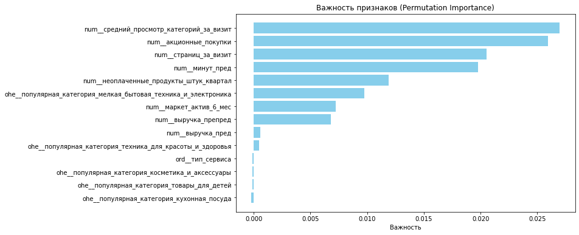

```python
# Вычисляем важность признаков с помощью перестановки
result = permutation_importance(best_model, X_train_transformed, y_train, scoring='roc_auc')

# Создаем DataFrame для удобства работы с результатами
importance_df = pd.DataFrame({
    'Feature': feature_names,
    'Importance': result.importances_mean,
    'Std': result.importances_std
})

# Сортируем по важности
importance_df = importance_df.sort_values(by='Importance', ascending=True)

# Строим график важности признаков
plt.figure(figsize=(10, 6))
plt.barh(importance_df['Feature'], importance_df['Importance'], color='skyblue')
plt.xlabel('Важность')
plt.title('Важность признаков (Permutation Importance)')
plt.show()
```

```python
# Получаем соответствие между числами и метками
label_mapping = dict(enumerate(label_encoder.classes_))
print(label_mapping)
```

```
{0: 'прежний_уровень', 1: 'снизилась'}
```

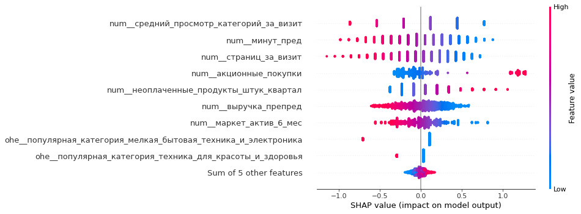

```python
# Инициализируем SHAP explainer с извлеченной моделью
explainer = shap.LinearExplainer(best_model, X_train_transformed_df)

# Рассчитываем SHAP значения
shap_values = explainer(X_train_transformed_df)

# Строим график beeswarm
shap.plots.beeswarm(shap_values)
```

`средний_просмотр_категорий_за_визит` - пользователи, активно просматривающие категории, склонны сохранять прежний уровень покупательской активности.

- Это может быть связано с тем, что клиенты, активно ищущие что-то, в итоге находят нужные товары и продолжают совершать покупки

`минут_пред` (количество минут за предыдущий месяц) - чем больше времени пользователь провел на платформе в предыдущем месяце, тем выше вероятность сохранения его покупательской активности.

`страниц_за_визит` (количество страниц за визит) - высокие значения (красные точки) преимущественно cлева: чем больше страниц пользователь просматривает за визит, тем выше вероятность сохранения покупательской активности.

`акционные_покупки` - Большие значения срава отрицательно влияет на сохранение активности пользователя. Возможно, это говорит о том, что пользователи, пришедшие по рекламе и ожидающие скидки, как правило, теряют интерес, когда акция заканчивается.

`маркет_актив_6_мес` - Высокие значения (красные точки) преимущественно слева: активное воздействие маркетинговых коммуникаций в прошлом склонно сохранять прежний уровень активности.

- Маркетинговые усилия оказывают положительное влияние на удержание пользователей и поддержание их активности.

`неоплаченные_продукты_штук_квартал` - Чем меньше число неоплаченных продуктов, тем больше вероятность сохранения активности.

`выручка_препред` - Высокие значения (красные точки) высокая выручка в прошлом месяце ведет к сохранению активности.

> **Промежуточный итоги:**

> Оптимизация маркетинга:
> - Запускать персонализированные акции для постоянных клиентов.
> - Усиливать маркетинг среди пользователей с высоким уровнем вовлеченности.

> Стимулирование повторных покупок:
> - Развивать программы лояльности для клиентов с высокой прошлой выручкой.
> - Упрощать процесс завершения заказа (минимизировать неоплаченные товары).

## Сегментация покупателей

Выбранный сегмент — это группа клиентов с высокой вероятностью снижения покупательской активности и наиболее высокой прибыльностью. Этот сегмент особенно важен для бизнеса, так как позволяет сосредоточить усилия на удержании ценных клиентов с высокой платежеспособностью.

```python
# Предскажем вероятности для всей выборки
market_data_copy = market_data.copy()

market_data_copy['вероятность_снижения'] = randomized_search.best_estimator_.predict_proba(X)[:, 1]

# Объединяем с данными о прибыльности
market_data_copy = pd.merge(market_data_copy, money, on='id', how='inner')

display(market_data_copy.head())
market_data_copy.shape
```

|  | id | покупательская_активность | тип_сервиса | маркет_актив_6_мес | акционные_покупки | популярная_категория | средний_просмотр_категорий_за_визит | неоплаченные_продукты_штук_квартал | страниц_за_визит | выручка_пред | выручка_препред | минут_пред | вероятность_снижения | прибыль |
| --- | --- | --- | --- | --- | --- | --- | --- | --- | --- | --- | --- | --- | --- | --- |
| 0 | 215349 | снизилась | премиум | 4.4 | 0.75 | товары_для_детей | 4 | 4 | 5 | 5216.0 | 4472.0 | 12 | 0.806701 | 4.16 |
| 1 | 215350 | снизилась | стандарт | 4.9 | 0.14 | домашний_текстиль | 5 | 2 | 5 | 5457.5 | 4826.0 | 8 | 0.425859 | 3.13 |
| 2 | 215351 | снизилась | стандарт | 3.2 | 0.99 | товары_для_детей | 5 | 0 | 4 | 6158.0 | 4793.0 | 11 | 0.776518 | 4.87 |
| 3 | 215352 | снизилась | стандарт | 5.1 | 0.94 | товары_для_детей | 3 | 2 | 2 | 5807.5 | 4594.0 | 8 | 0.906479 | 4.21 |
| 4 | 215353 | снизилась | стандарт | 3.3 | 0.26 | домашний_текстиль | 4 | 1 | 4 | 4738.5 | 5124.0 | 10 | 0.524736 | 3.95 |

```
(1296, 14)
```

Объединение таблиц произошло успешно.

Для того чтобы определить, какие пользователи имеют большую вероятность к снижению активности и при этом являются наиболее прибыльными выполним операции с фильтрацией. Установим порог, превышение которого будет обозначать вероятность снижения активности

```python
# Установка порог для вероятности снижения активности
threshold = 0.7

# Фильтруем клиентов с высокой вероятностью снижения активности
high_risk_customers = market_data_copy[market_data_copy['вероятность_снижения'] > threshold]

# Определим порог для прибыльности (верхний квартиль)
profit_threshold = high_risk_customers['прибыль'].quantile(0.75)

# Фильтруем клиентов с высокой прибыльностью
target_segment = high_risk_customers[high_risk_customers['прибыль'] > profit_threshold]

print(f"Размер целевого сегмента: {len(target_segment)} клиентов")
display(target_segment.head())
```

```
Размер целевого сегмента: 86 клиентов
```

|  | id | покупательская_активность | тип_сервиса | маркет_актив_6_мес | акционные_покупки | популярная_категория | средний_просмотр_категорий_за_визит | неоплаченные_продукты_штук_квартал | страниц_за_визит | выручка_пред | выручка_препред | минут_пред | вероятность_снижения | прибыль |
| --- | --- | --- | --- | --- | --- | --- | --- | --- | --- | --- | --- | --- | --- | --- |
| 2 | 215351 | снизилась | стандарт | 3.2 | 0.99 | товары_для_детей | 5 | 0 | 4 | 6158.0 | 4793.0 | 11 | 0.776518 | 4.87 |
| 7 | 215356 | снизилась | стандарт | 4.2 | 0.14 | косметика_и_аксессуары | 2 | 2 | 3 | 4146.5 | 4433.0 | 6 | 0.821086 | 4.93 |
| 17 | 215368 | снизилась | премиум | 3.8 | 0.24 | техника_для_красоты_и_здоровья | 2 | 2 | 1 | 5823.0 | 4536.0 | 11 | 0.762745 | 6.27 |
| 32 | 215384 | снизилась | стандарт | 4.0 | 0.34 | косметика_и_аксессуары | 2 | 3 | 3 | 3584.0 | 4226.0 | 11 | 0.842604 | 4.78 |
| 36 | 215388 | снизилась | стандарт | 3.5 | 0.99 | домашний_текстиль | 4 | 2 | 2 | 3188.0 | 4182.0 | 10 | 0.910296 | 5.16 |

Чтобы определить статению для увеличения покупательской активности проведем анлиз полученных данных в таблице `target_segment`.

Построим гистограммы, чтобы определить различия между всеми клиентами и целевым сегментом.

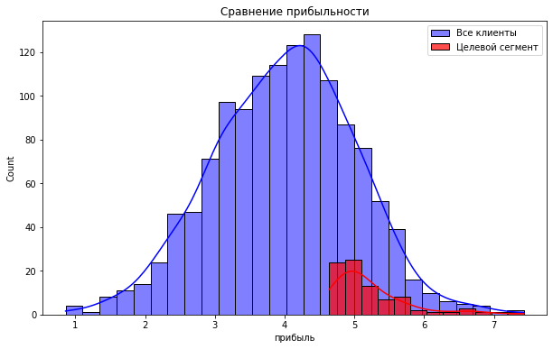

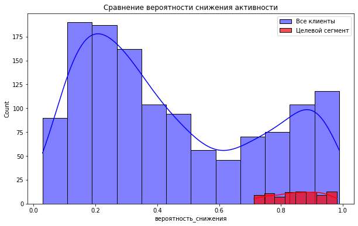

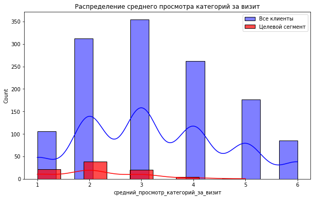

```python
# Сравнение прибыльности
plt.figure(figsize=(10, 6))
sns.histplot(market_data_copy['прибыль'], color='blue', label='Все клиенты', kde=True, alpha=0.5)
sns.histplot(target_segment['прибыль'], color='red', label='Целевой сегмент', kde=True, alpha=0.7)
plt.title('Сравнение прибыльности')
plt.legend()
plt.show()

# Сравнение вероятности снижения активности
plt.figure(figsize=(10, 6))
sns.histplot(market_data_copy['вероятность_снижения'], color='blue', label='Все клиенты', kde=True, alpha=0.5)
sns.histplot(target_segment['вероятность_снижения'], color='red', label='Целевой сегмент', kde=True, alpha=0.7)
plt.title('Сравнение вероятности снижения активности')
plt.legend()
plt.show()

# Сравнение активности с магазином
plt.figure(figsize=(10, 6))
sns.histplot(market_data_copy['средний_просмотр_категорий_за_визит'], color='blue', label='Все клиенты', kde=True, alpha=0.5)
sns.histplot(target_segment['средний_просмотр_категорий_за_визит'], color='red', label='Целевой сегмент', kde=True, alpha=0.7)
plt.title('Распределение среднего просмотра категорий за визит')
plt.legend()
plt.show()
```

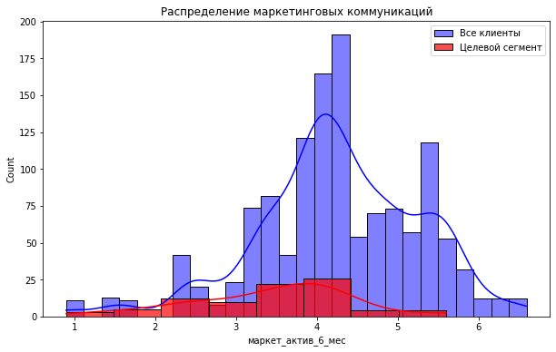

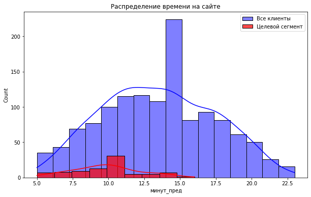

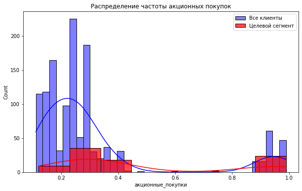

```python
# Сравнение маркетинговых коммуникаций
plt.figure(figsize=(10, 6))
sns.histplot(market_data_copy['маркет_актив_6_мес'], color='blue', label='Все клиенты', kde=True, alpha=0.5)
sns.histplot(target_segment['маркет_актив_6_мес'], color='red', label='Целевой сегмент', kde=True, alpha=0.7)
plt.title('Распределение маркетинговых коммуникаций')
plt.legend()
plt.show()

# Сравнение времени на сайте
plt.figure(figsize=(10, 6))
sns.histplot(market_data_copy['минут_пред'], color='blue', label='Все клиенты', kde=True, alpha=0.5)
sns.histplot(target_segment['минут_пред'], color='red', label='Целевой сегмент', kde=True, alpha=0.7)
plt.title('Распределение времени на сайте')
plt.legend()
plt.show()

# Сравнение частоты акционных покупок
plt.figure(figsize=(10, 6))
sns.histplot(market_data_copy['акционные_покупки'], color='blue', label='Все клиенты', kde=True, alpha=0.5)
sns.histplot(target_segment['акционные_покупки'], color='red', label='Целевой сегмент', kde=True, alpha=0.7)
plt.title('Распределение частоты акционных покупок')
plt.legend()
plt.show()
```

- Если рассматривать график распределение маркетинговых коммуникаций, можно предположить, что на данный вид пользователей могут отрицательно относиться к маркетинговым коммуникациям. Возможно следует использовать определенные, более удобные виды коммуникаций, чтобы сохранить платежеспособных клиентов.
- Распределение времени на сайте, отображает, что целевой сегмент, не склонен проводит время на сайте и это способствует потере клиента.
- Распределение частоты акционных покупок, отображает, что количество акционных покупок снижает активность выбранного сегмента пользователей. Возможно, это приходящий пользователь, закупавшийся по акции.
- Имеет смысл, определить популярные категории среди целевого сегмента, для определения предпочитаемых категорий товара.

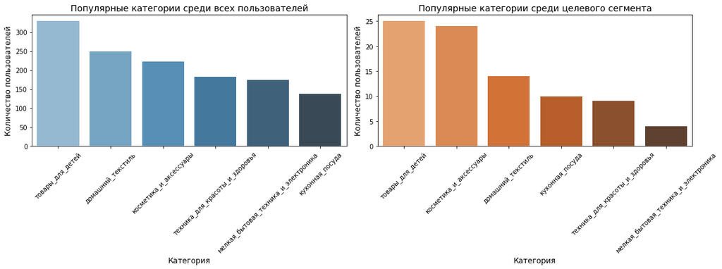

```python
# Определение популярных категорий среди всех пользователей
all_users_categories = market_data_copy['популярная_категория'].value_counts()

# Определение популярных категорий среди целевого сегмента
segment_categories = target_segment['популярная_категория'].value_counts()

# Построение графиков
plt.figure(figsize=(16, 6))

# График для всех пользователей
plt.subplot(1, 2, 1)
sns.barplot(x=all_users_categories.index, y=all_users_categories.values, palette='Blues_d')
plt.title('Популярные категории среди всех пользователей', fontsize=14)
plt.xlabel('Категория', fontsize=12)
plt.ylabel('Количество пользователей', fontsize=12)
plt.xticks(rotation=45)

# График для целевого сегмента
plt.subplot(1, 2, 2)
sns.barplot(x=segment_categories.index, y=segment_categories.values, palette='Oranges_d')
plt.title('Популярные категории среди целевого сегмента', fontsize=14)
plt.xlabel('Категория', fontsize=12)
plt.ylabel('Количество пользователей', fontsize=12)
plt.xticks(rotation=45)

plt.tight_layout()
plt.show()
```

Среди целевых клиентов наиболее популярны товары для детей, косметика и аксессуары, домашний текстиль и кухонная посуда.

Можно предложить следующие стратегии для бизнеса, подходящие целевому сегменту:

- Разработать персонализированные предложения (скидки, промокоды или бонусы) на популярные категории товаров.
- Придумать деликатные индивидуальные рекомендации через email-рассылку или push-уведомления, основанные на истории покупок.
- Добавить функционал "быстрого заказа" для повторных покупок., чтобы клиенты могли быстрее находить нужные товары.
- Предлагать персонализированные подборки товаров на главной странице после входа пользователя, это может помочь в удержании клиентов.

## Общий вывод

Сделайте общий вывод:

- опишите задачу;
- опишите исходные данные и проведённую предобработку;
- напишите, что вы сделали для поиска лучшей модели;
- укажите лучшую модель;
- добавьте выводы и дополнительные предложения для выбранного сегмента покупателей.

Целью проекта было разработать решение, которое позволит персонализировать предложения постоянным клиентам интернет-магазина «В один клик», чтобы увеличить их покупательскую активность. Особое внимание уделялось сегменту клиентов с высокой вероятностью снижения активности и высокой прибыльностью. Для этого требовалось:

- Промаркировать уровень финансовой активности постоянных покупателей («снизилась» или «прежний уровень»).
- Собрать данные о поведении клиентов на сайте, их коммуникации с компанией, продуктовом и покупательском поведении.
- Построить модель машинного обучения, которая предскажет вероятность снижения покупательской активности клиента в следующие три месяца.
- Используя данные модели и данные о прибыльности клиентов, выделить сегменты покупателей и разработать для них персонализированные предложения

**Для анализа были предоставлены следующие таблицы:**

1. **`market_file.csv`:** содержит данные о поведении покупателя на сайте, коммуникациях с покупателем и его продуктовом поведении.
2. **`market_money.csv`:** содержит данные о выручке, которую получает магазин с покупателя за разные периоды.
3. **`market_time.csv`:** содержит данные о времени (в минутах), которое покупатель провёл на сайте за разные периоды.
4. **`money.csv`:** содержит данные о среднемесячной прибыли продавца за последние 3 месяца.

**Что сделано для поиска лучшей модели**

Для поиска лучшей модели были выполнены следующие шаги:

1. **Подготовка данных:**
   - Использован `ColumnTransformer` для обработки категориальных и количественных признаков.
   - Категориальные признаки закодированы с помощью `OneHotEncoder` и `OrdinalEncoder`.
   - Количественные признаки масштабированы с использованием `StandardScaler` и `MinMaxScaler`.
2. **Обучение моделей:**
   - Обучены четыре модели: `KNeighborsClassifier`, `DecisionTreeClassifier`, `LogisticRegression`, `SVC`.
   - Для каждой модели подобраны гиперпараметры с помощью `RandomizedSearchCV`.
3. **Выбор метрики:**
   - В качестве метрики качества была выбрана ROC-AUC, так как она позволяет оценить способность модели различать классы даже при дисбалансе целевого признака.
4. **Анализ важности признаков:**
   - Для лучшей модели выполнен анализ важности признаков с помощью метода SHAP.
   - Выявлены ключевые признаки, влияющие на целевой признак: `средний_просмотр_категорий_за_визит`, `минут_пред`, `страниц_за_визит`, `акционные_покупки`, `маркет_актив_6_мес`, `неоплаченные_продукты_штук_квартал`, `num_выручка_препред`.

**Лучшая модель**

Лучшей моделью оказалась **`LogisticRegression`** с параметрами:

- `C=0.2`
- `class_weight='balanced'`
- Масштабирование данных: `MinMaxScaler`

Метрика ROC-AUC на тренировочной выборке составила **0.89**, а на тестовой выборке — **0.91**, что подтверждает отсутствие переобучения.

**Выводы и дополнительные предложения для выбранного сегмента покупателей**

**Сегмент клиентов:** На основе результатов моделирования и данных о прибыльности клиентов был выделен сегмент клиентов с высокой вероятностью снижения активности и высокой прибыльностью. Этот сегмент характеризуется:

- Низким уровнем просмотра каттегорий на сайте.
- Частыми акционными покупками.
- Высокой прибыльностью для компании.

**Дополнительные предложения для бизнеса:**

1. **Персонализированные акции на популярные категории:**
   - Разработать индивидуальные скидки, промокоды или бонусы на товары из категорий, которые чаще всего просматриваются и покупаются клиентами данного сегмента (например, товары для детей, косметика, домашний текстиль).
   - Отправлять персонализированные рекомендации через email-рассылку или push-уведомления, основанные на истории покупок.
2. **Оптимизация маркетинговых коммуникаций:**
   - Сократить количество рекламных сообщений для этого сегмента, чтобы не раздражать клиентов.
   - Использовать более качественные и релевантные каналы коммуникации (например, видеоролики, статьи или советы по использованию товаров).
3. **Улучшение пользовательского опыта на сайте:**
   - Упростить интерфейс сайта, чтобы клиенты могли быстрее находить нужные товары.
   - Добавить функционал "быстрого заказа" для повторных покупок.
   - Предлагать персонализированные подборки товаров на главной странице после входа пользователя.
4. **Стимулирование перехода в другие категории:**
   - Разработать рекомендательную систему, которая будет предлагать связанные товары (например, если клиент купил детскую одежду, предложить игрушки или аксессуары).
   - Добавлять баннеры с акциями на смежные категории товаров.

**Заключение**

В ходе проекта были успешно выполнены все этапы:

- Проведён детальный анализ данных, выявлены и устранены выбросы, пропуски и мультиколлинеарность.
- Обучены и протестированы несколько моделей машинного обучения, выбрана лучшая модель.
- Выделен сегмент клиентов с высокой вероятностью снижения активности и высокой прибыльностью.
- Разработаны конкретные предложения для бизнеса, направленные на увеличение покупательской активности в этом сегменте.

Результаты исследования могут быть использованы для удержания клиентов и повышения их покупательской активности.